# Tarea #4

Alejandro Zamora

17/03/2022

# Ejercicio 1 (35 puntos)

Cargue los datos que se encuentran en el archivo “estrellas.csv”, el conjunto de datos tiene 17898 observaciones y 9 variables en cada una. Específicamente, este dataset contiene información estadística de estrellas pulsares obtenidos por el trabajo High Time Resolution Universe Survey (https://arxiv.org/abs/1006.5744), y cuyas variables son.

• Media del perfil integrado  
• Desviaciación estándar del perfil integrado  
• Exceso de curtosis del perfil integrado  
• Asimetría del perfil integrado  
• Media de la curva DM-SNR  
• Desviación estándar de la curva DM-SNR  
• Exceso de curtosis de la curva DM-SNR  
• Asimetría de la curva DM-SNR  
• Clase de la estrella

```r
library(ggplot2)
library(tidyr)
library(normtest)
library(dplyr)
library(rpart)
library(plotly)
library(ggraph)
library("readxl")
library(ROCR)
library(corrplot)
library(ggplot2)
library(ggpubr)
library(PerformanceAnalytics)
library(ISLR)
library(tidyverse)
library(covTestR)
library(rmdformats)
library(pROC)
library("mvnormtest")
library(factoextra)
library(DT)
library(caret)
library(recipes)
library(e1071)
library(randomForest)
```

```r
library("readxl")
estrellas <- read_csv("DatosEstrellas.csv")
```

```r
DT::datatable(estrellas[1:9,])
```

|  | Mean of the integrated profile | Standard deviation of the integrated profile | Excess kurtosis of the integrated profile | Skewness of the integrated profile | Mean of the DM-SNR curve | Standard deviation of the DM-SNR curve | Excess kurtosis of the DM-SNR curve | Skewness of the DM-SNR curve | target_class |
| --- | --- | --- | --- | --- | --- | --- | --- | --- | --- |
| 1 | 140.5625 | 55.68378214 | -0.234571412 | -0.699648398 | 3.199832776 | 19.11042633 | 7.975531794 | 74.24222492 | 0 |
| 2 | 102.5078125 | 58.88243001 | 0.465318154 | -0.515087909 | 1.677257525 | 14.86014572 | 10.57648674 | 127.3935796 | 0 |
| 3 | 103.015625 | 39.34164944 | 0.323328365 | 1.051164429 | 3.121237458 | 21.74466875 | 7.735822015 | 63.17190911 | 0 |
| 4 | 136.75 | 57.17844874 | -0.068414638 | -0.636238369 | 3.642976589 | 20.9592803 | 6.89649891 | 53.59366067 | 0 |
| 5 | 88.7265625 | 40.67222541 | 0.600866079 | 1.123491692 | 1.178929766 | 11.4687196 | 14.26957284 | 252.5673058 | 0 |
| 6 | 93.5703125 | 46.69811352 | 0.53190485 | 0.416721117 | 1.636287625 | 14.54507425 | 10.6217484 | 131.3940043 | 0 |
| 7 | 119.484375 | 48.76505927 | 0.03146022 | -0.112167573 | 0.99916388 | 9.279612239 | 19.20623018 | 479.7565669 | 0 |
| 8 | 130.3828125 | 39.84405561 | -0.158322759 | 0.389540448 | 1.220735786 | 14.37894124 | 13.53945602 | 198.2364565 | 0 |
| 9 | 107.25 | 52.62707834 | 0.452688025 | 0.170347382 | 2.331939799 | 14.48685311 | 9.001004441 | 107.9725056 | 0 |

Convertimos la variable class a factor.

```r
estrellas$target_class <- as.factor(estrellas$target_class)
```

```r
# Número de datos ausentes por variable
map_dbl(estrellas, .f = function(x){sum(is.na(x))})
```

```
##               Mean of the integrated profile
##                                            0
## Standard deviation of the integrated profile
##                                            0
##    Excess kurtosis of the integrated profile
##                                            0
##           Skewness of the integrated profile
##                                            0
##                     Mean of the DM-SNR curve
##                                            0
##       Standard deviation of the DM-SNR curve
##                                            0
##          Excess kurtosis of the DM-SNR curve
##                                            0
##                 Skewness of the DM-SNR curve
##                                            0
##                                 target_class
##                                            0
```

```r
estrellas %>% map_lgl(.f = function(x){any(!is.na(x) & x == "")})
```

```
##               Mean of the integrated profile
##                                        FALSE
## Standard deviation of the integrated profile
##                                        FALSE
##    Excess kurtosis of the integrated profile
##                                        FALSE
##           Skewness of the integrated profile
##                                        FALSE
##                     Mean of the DM-SNR curve
##                                        FALSE
##       Standard deviation of the DM-SNR curve
##                                        FALSE
##          Excess kurtosis of the DM-SNR curve
##                                        FALSE
##                 Skewness of the DM-SNR curve
##                                        FALSE
##                                 target_class
##                                        FALSE
```

Distribución de la variable respuesta

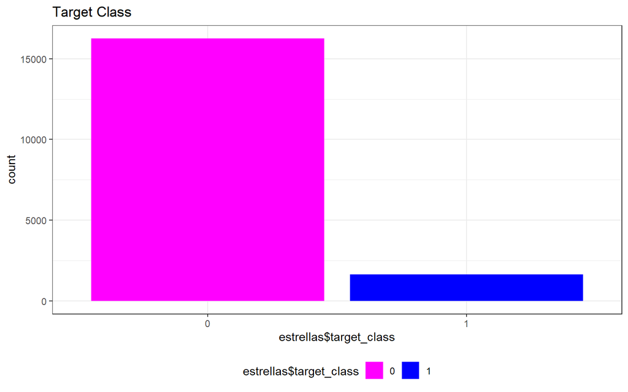

```r
ggplot(data = estrellas, aes(x = estrellas$target_class, y = ..count.., fill = estrellas$target_class )) +
  geom_bar() +
  scale_fill_manual(values = c("magenta", "blue")) +
  labs(title = "Target Class") +
  theme_bw() +
  theme(legend.position = "bottom")
```

Vemos a nivel de porcentajes la diferencias en cantidad.

```r
tmp<-table(estrellas$target_class)
df<-as.data.frame(tmp)
colnames(df)<-c("class","Cantidad")
df$Porcentaje<-df$Cantidad/sum(df$Cantidad)
DT:::datatable(df)%>%formatPercentage("Porcentaje",2)
```

|  | class | Cantidad | Porcentaje |
| --- | --- | --- | --- |
| 1 | 0 | 16259 | 0.908425522404738 |
| 2 | 1 | 1639 | 0.091574477595262 |

Se valida que el porcentaje de acierto sea superior a lo esperado por azar.

```r
n.observaciones <- nrow(estrellas)
predicciones <- rep(x = 0,  n.observaciones)
mean(predicciones == estrellas$target_class) * 100
```

```
## [1] 90.84255
```

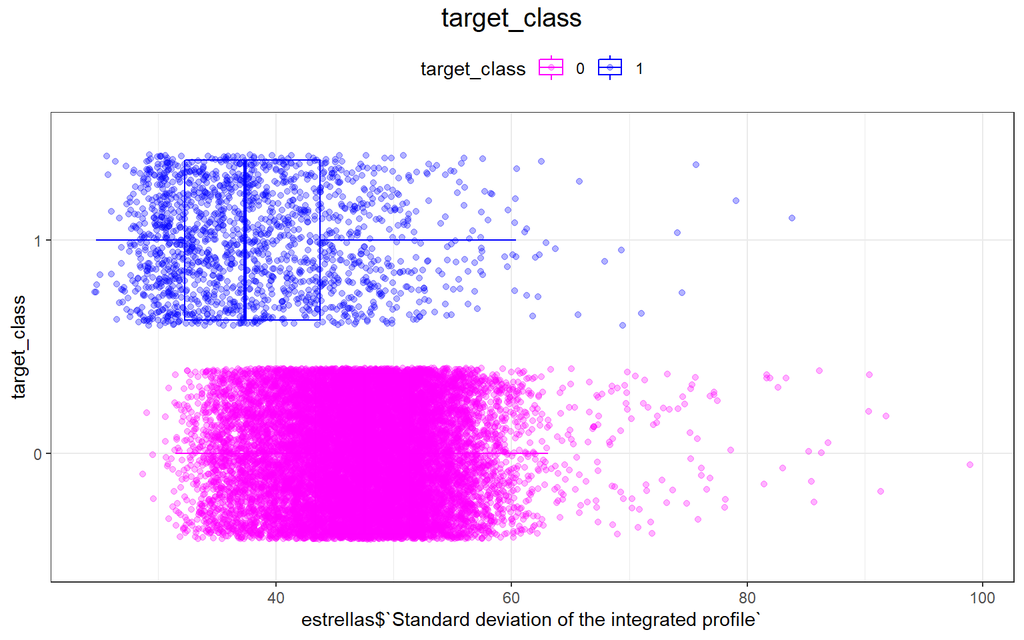

```r
p2 <- ggplot(data = estrellas, aes(x = estrellas$`Standard deviation of the integrated profile`, y = target_class, color = target_class)) +
      geom_boxplot(outlier.shape = NA) +
      geom_jitter(alpha = 0.3, width = 0.15) +
      scale_color_manual(values = c("magenta", "blue")) +
      theme_bw()
final.plot <- ggarrange(p2, legend = "top")
final.plot <- annotate_figure(final.plot, top = text_grob("target_class", size = 15))
final.plot
```

Estudio de la Correlación entre variables continuas

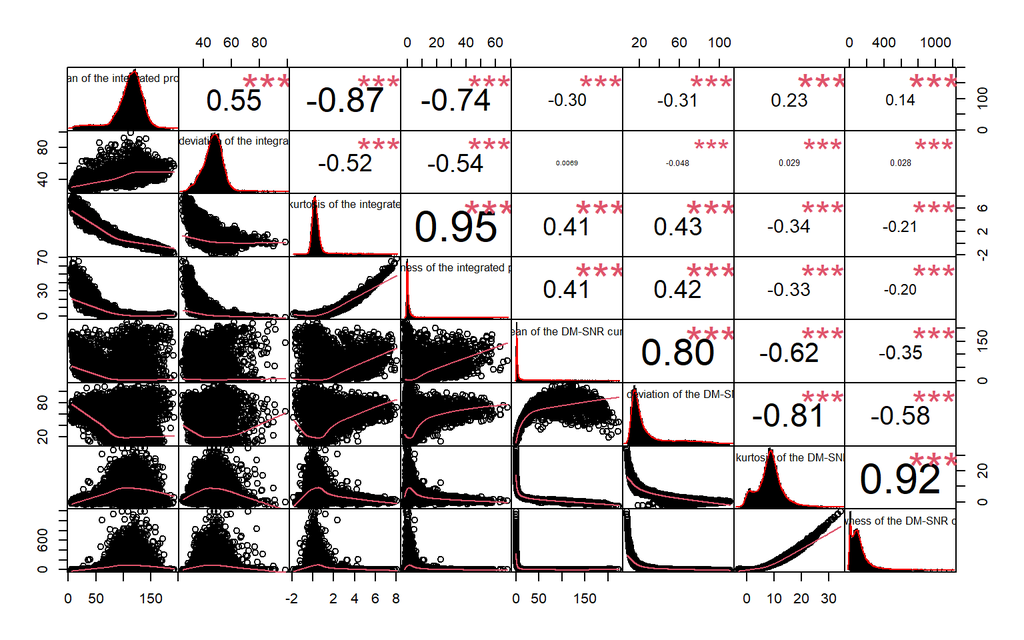

```r
chart.Correlation(estrellas[,1:8], histogram = TRUE, method = "pearson")
```

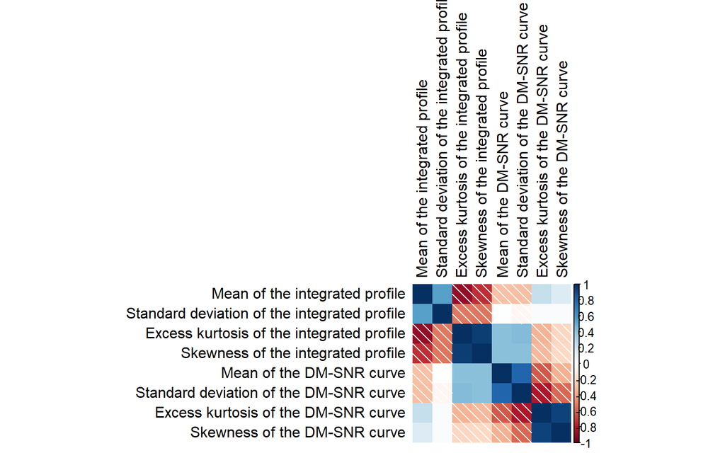

```r
corrplot(cor(estrellas[,1:8]),        # Matriz de correlación
         method = "shade", # Método para el gráfico de correlación
         type = "full",    # Estilo del gráfico (también "upper" y "lower")
         diag = TRUE,      # Si TRUE (por defecto), añade la diagonal
         tl.col = "black", # Color de las etiquetas
         bg = "white",     # Color de fondo
         title = "",       # Título
         col = NULL)
```

Función de indicadores de Calidad.

```r
indicadores.calidad<-function(matriz.confusion)
{
  Total.obs<-sum(matriz.confusion)
  a<-matriz.confusion[1,1]
  b<-matriz.confusion[1,2]
  c<-matriz.confusion[2,1]
  d<-matriz.confusion[2,2]

  Precision.Global<- (a+d)/Total.obs
  Error.Global<- 1 - Precision.Global
  Precision.Positiva<- d/(c+d)
  Precision.Negativa<- a/(a+b)
  Falsos.Positivos<- c/(c+d)
  Falsos.Negativos<-b/(a+b)
  Asertividad.Positiva<-d/(b+d)
  Asertividad.Negatividad<-a/(a+c)

  Indicadores<-data.frame(
    Precision.Global = Precision.Global,
    Error.Global = Error.Global,
    Precision.Positiva = Precision.Positiva,
    Precision.Negativa = Precision.Negativa,
    Falsos.Positivos = Falsos.Positivos,
    Falsos.Negativos = Falsos.Negativos,
    Asertividad.Positiva = Asertividad.Positiva,
    Asertividad.Negatividad = Asertividad.Negatividad
  )

  return(Indicadores)
}
```

Realice lo siguiente:

## 1. Cree dos datasets:

1. 80% de los datos para training
2. 20% para testing

```r
set.seed(123)
# Se crean los índices de las observaciones de entrenamiento
train <- createDataPartition(y = estrellas$target_class, p = 0.8, list = FALSE, times = 1)
estrellas.train <- estrellas[train, ]
estrellas.test  <- estrellas[-train, ]
```

```r
pro.train<-as.data.frame(table(estrellas.train$target_class))
pro.test<-as.data.frame(table(estrellas.test$target_class))

colnames(pro.train)<-c("target_class","Q.train")

pro.train$Q.test<-pro.test$Freq

pro.train$Porc.train<-pro.train$Q.train/sum(pro.train$Q.train)
pro.train$Porc.test<-pro.train$Q.test/sum(pro.train$Q.test)

DT::datatable(pro.train)%>%formatPercentage(c("Porc.train","Porc.test"),2)
```

|  | target_class | Q.train | Q.test | Porc.train | Porc.test |
| --- | --- | --- | --- | --- | --- |
| 1 | 0 | 13008 | 3251 | 0.908379888268156 | 0.90860816098379 |
| 2 | 1 | 1312 | 327 | 0.0916201117318436 | 0.0913918390162102 |

```r
objeto.recipe <- recipe(formula = target_class ~ `Mean of the integrated profile` + `Standard deviation of the integrated profile` + `Excess kurtosis of the integrated profile` + `Mean of the DM-SNR curve` + `Standard deviation of the DM-SNR curve` + `Excess kurtosis of the DM-SNR curve` + `Skewness of the DM-SNR curve`, data =  estrellas.train)
objeto.recipe
```

```
## Recipe
##
## Inputs:
##
##       role #variables
##    outcome          1
##  predictor          7
```

```r
tmp<-estrellas%>% dplyr::select(`Mean of the integrated profile`, `Standard deviation of the integrated profile`, `Excess kurtosis of the integrated profile`, `Mean of the DM-SNR curve`, `Standard deviation of the DM-SNR curve`, `Excess kurtosis of the DM-SNR curve`, `Skewness of the DM-SNR curve`) %>%
          nearZeroVar(saveMetrics = TRUE)

DT::datatable(tmp)%>%formatPercentage("percentUnique",2)%>%formatRound("freqRatio",2)
```

|  | freqRatio | percentUnique | zeroVar | nzv |
| --- | --- | --- | --- | --- |
| Mean of the integrated profile | 1.33333333333333 | 48.1953290870488 | False | False |
| Standard deviation of the integrated profile | 1 | 99.7988602078445 | False | False |
| Excess kurtosis of the integrated profile | 2 | 99.9944127835512 | False | False |
| Mean of the DM-SNR curve | 1 | 50.284948038887 | False | False |
| Standard deviation of the DM-SNR curve | 2 | 99.9776511342049 | False | False |
| Excess kurtosis of the DM-SNR curve | 4 | 99.9832383506537 | False | False |
| Skewness of the DM-SNR curve | 4 | 99.9832383506537 | False | False |

```r
objeto.recipe <- objeto.recipe %>% step_nzv(all_predictors())
objeto.recipe <- objeto.recipe %>% step_nzv(all_predictors())
```

```r
objeto.recipe <- objeto.recipe %>% step_center(all_numeric())
objeto.recipe <- objeto.recipe %>% step_scale(all_numeric())
```

```r
objeto.recipe <- objeto.recipe %>% step_dummy(all_nominal(), -all_outcomes())
trained.recipe <- prep(objeto.recipe, training = estrellas.train)
```

```r
trained.recipe
```

```
## Recipe
##
## Inputs:
##
##       role #variables
##    outcome          1
##  predictor          7
##
## Training data contained 14320 data points and no missing data.
##
## Operations:
##
## Sparse, unbalanced variable filter removed no terms [trained]
## Sparse, unbalanced variable filter removed no terms [trained]
## Centering for Mean of the integrated profile, Standard deviat... [trained]
## Scaling for Mean of the integrated profile, Standard deviat... [trained]
## Dummy variables were *not* created since no columns were selected. [trained]
```

```r
training.set<-estrellas.train.prep <- bake(trained.recipe, new_data = estrellas.train)
test.set<-estrellas.test.prep  <- bake(trained.recipe, new_data = estrellas.test)
training.set<-as.data.frame(training.set)
test.set<-as.data.frame(test.set)
glimpse(estrellas.train.prep)
```

```
## Rows: 14,320
## Columns: 8
## $ `Mean of the integrated profile`               <dbl> 1.14861507, -0.33727507~
## $ `Standard deviation of the integrated profile` <dbl> 1.32598350, 1.79142847,~
## $ `Excess kurtosis of the integrated profile`    <dbl> -0.6705656472, -0.00955~
## $ `Mean of the DM-SNR curve`                     <dbl> -0.31826885, -0.3699013~
## $ `Standard deviation of the DM-SNR curve`       <dbl> -0.36787688, -0.5861245~
## $ `Excess kurtosis of the DM-SNR curve`          <dbl> -0.075888855, 0.5014880~
## $ `Skewness of the DM-SNR curve`                 <dbl> -0.28821396, 0.20885129~
## $ target_class                                   <fct> 0, 0, 0, 0, 0, 0, 0, 0,~
```

## 2. Seleccione el mejor núcleo para SVM (“linear”,“radial”,“polynomial”,“sigmoid”), para esto deben utilizar el siguiente código (Y es la variable a predecir):

Probando los Nucleos, los que mejores indicadores marcaron fueron lineal y radial.

Matriz de confusión para nucelo radial

```r
clasificadorSVM  <- e1071::svm(estrellas.train$target_class ~ ., data = estrellas.train, type = 'C-classification', kernel = 'radial')
```

```r
pred.valid.svm <- predict(clasificadorSVM, newdata = estrellas.test)
matrizConfusionSVM <- table(test.set$target_class, pred.valid.svm)
matrizConfusionSVM
```

```
##    pred.valid.svm
##        0    1
##   0 3234   17
##   1   60  267
```

```r
indicadores.calidad(matrizConfusionSVM)
```

```
##   Precision.Global Error.Global Precision.Positiva Precision.Negativa
## 1        0.9784796    0.0215204          0.8165138          0.9947708
##   Falsos.Positivos Falsos.Negativos Asertividad.Positiva
## 1        0.1834862       0.00522916            0.9401408
##   Asertividad.Negatividad
## 1               0.9817851
```

Nucleo lineal.

```r
clasificadorSVM  <- e1071::svm(estrellas.train$target_class ~ ., data = estrellas.train, type = 'C-classification', kernel = 'linear')
pred.valid.svm <- predict(clasificadorSVM, newdata = estrellas.test)
```

Matriz de confusión para nucelo lineal

```r
matrizConfusionSVM <- table(test.set$target_class, pred.valid.svm)
matrizConfusionSVM
```

```
##    pred.valid.svm
##        0    1
##   0 3234   17
##   1   63  264
```

```r
indicadores.calidad(matrizConfusionSVM)
```

```
##   Precision.Global Error.Global Precision.Positiva Precision.Negativa
## 1        0.9776411   0.02235886          0.8073394          0.9947708
##   Falsos.Positivos Falsos.Negativos Asertividad.Positiva
## 1        0.1926606       0.00522916            0.9395018
##   Asertividad.Negatividad
## 1               0.9808917
```

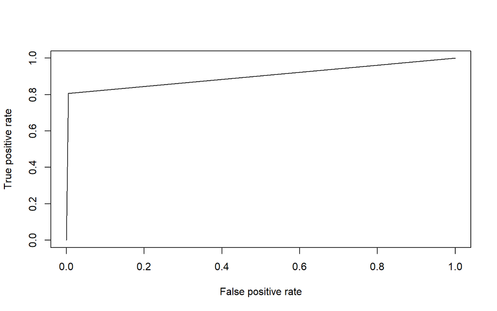

```r
predSVM <- prediction(as.numeric(pred.valid.svm), as.numeric(test.set$target_class))
perfSVM <- performance(predSVM, "tpr", "fpr")
plot(perfSVM)
```

```r
auc.pSVM<-performance(predSVM,"auc")
```

Nucleo sigmoid

```r
clasificadorSVM  <- e1071::svm(estrellas.train$target_class ~ ., data = estrellas.train, type = 'C-classification', kernel = 'sigmoid')
pred.valid.svm <- predict(clasificadorSVM, newdata = estrellas.test)
```

Matriz de confusión para nucelo sigmoid

```r
matrizConfusionSVM <- table(test.set$target_class, pred.valid.svm)
matrizConfusionSVM
```

```
##    pred.valid.svm
##        0    1
##   0 3008  243
##   1  238   89
```

```r
indicadores.calidad(matrizConfusionSVM)
```

```
##   Precision.Global Error.Global Precision.Positiva Precision.Negativa
## 1        0.8655674    0.1344326          0.2721713          0.9252538
##   Falsos.Positivos Falsos.Negativos Asertividad.Positiva
## 1        0.7278287       0.07474623            0.2680723
##   Asertividad.Negatividad
## 1                0.926679
```

Nucleo polynomial

```r
clasificadorSVM  <- e1071::svm(estrellas.train$target_class ~ ., data = estrellas.train, type = 'C-classification', kernel = 'polynomial')
pred.valid.svm <- predict(clasificadorSVM, newdata = estrellas.test)
```

Matriz de confusión para nucelo polynomial

```r
matrizConfusionSVM <- table(test.set$target_class, pred.valid.svm)
matrizConfusionSVM
```

```
##    pred.valid.svm
##        0    1
##   0 3235   16
##   1   65  262
```

```r
indicadores.calidad(matrizConfusionSVM)
```

```
##   Precision.Global Error.Global Precision.Positiva Precision.Negativa
## 1        0.9773617   0.02263835          0.8012232          0.9950784
##   Falsos.Positivos Falsos.Negativos Asertividad.Positiva
## 1        0.1987768      0.004921563             0.942446
##   Asertividad.Negatividad
## 1                0.980303
```

## 3. Entrene los demás modelos:

### a. Bayes

Naive Bayes Classifier

```r
set.seed(1234)
clasificadorBayes <- naiveBayes(target_class ~ ., data = estrellas.train)
```

Prediccion en el conjunto de validaciones.

```r
pred.valid.bayes <- predict(clasificadorBayes, newdata = estrellas.test)
```

Matriz de confusión de Bayes.

```r
matrizConfusionBayes <- table(estrellas.test$target_class, pred.valid.bayes)
matrizConfusionBayes
```

```
##    pred.valid.bayes
##        0    1
##   0 3093  158
##   1   48  279
```

```r
indicadores.calidad(matrizConfusionBayes)
```

```
##   Precision.Global Error.Global Precision.Positiva Precision.Negativa
## 1        0.9424259   0.05757406           0.853211          0.9513996
##   Falsos.Positivos Falsos.Negativos Asertividad.Positiva
## 1         0.146789       0.04860043            0.6384439
##   Asertividad.Negatividad
## 1               0.9847182
```

Curva ROC para bayes.

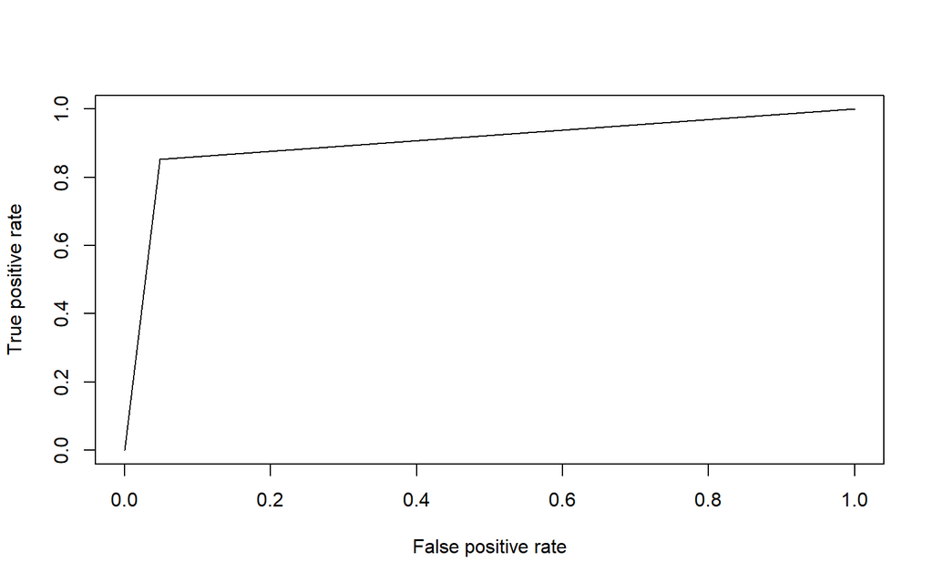

```r
predBayes <- prediction(as.numeric(pred.valid.bayes), as.numeric(test.set$target_class))
perfBayes <- performance(predBayes, "tpr", "fpr")
plot(perfBayes)
```

```r
auc.pBayes<-performance(predBayes,"auc")
```

### b. Árboles

```r
set.seed(1234)
clasificadorDT <- rpart(target_class ~ ., data = estrellas.train)
```

```r
pred.valid.DT <- predict(clasificadorDT, newdata = estrellas.test, type = 'class')
```

```r
matrizConfusionDT <- table(estrellas.test$target_class, pred.valid.DT)
matrizConfusionDT
```

```
##    pred.valid.DT
##        0    1
##   0 3224   27
##   1   61  266
```

Indicadores de calidad para Arboles

```r
indicadores.calidad(matrizConfusionDT)
```

```
##   Precision.Global Error.Global Precision.Positiva Precision.Negativa
## 1        0.9754053   0.02459475          0.8134557          0.9916949
##   Falsos.Positivos Falsos.Negativos Asertividad.Positiva
## 1        0.1865443      0.008305137            0.9078498
##   Asertividad.Negatividad
## 1               0.9814307
```

Curva ROC de arboles.

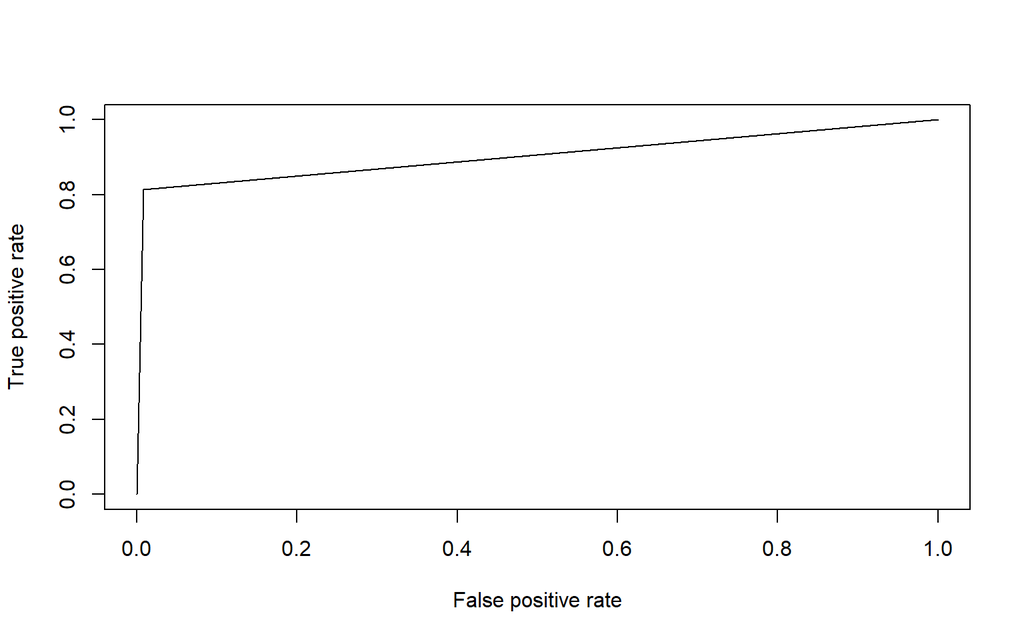

```r
predDT <- prediction(as.numeric(pred.valid.DT), as.numeric(estrellas.test$target_class))
perfDT <- performance(predDT, "tpr", "fpr")
plot(perfDT)
```

```r
auc.pDT<-performance(predDT,"auc")
print(auc.pDT)
```

```
## A performance instance
##   'Area under the ROC curve'
```

### c. Bosques Aleatorios

```r
names(estrellas.train) <- make.names(names(estrellas.train))
names(estrellas.test) <- make.names(names(estrellas.test))
clasificadorRF <- randomForest(target_class ~ ., data = estrellas.train, ntree = 250)
```

```r
ed.valid.RF <- predict(clasificadorRF, newdata = estrellas.test)
pred.valid.RF <- predict(clasificadorRF, newdata = estrellas.test)
```

Matriz de confusión de Random Forest.

```r
matrizConfusionRF <- table(estrellas.test$target_class, pred.valid.RF)
matrizConfusionRF
```

```
##    pred.valid.RF
##        0    1
##   0 3232   19
##   1   54  273
```

Indicadores de calidad para random Forest

```r
indicadores.calidad(matrizConfusionRF)
```

```
##   Precision.Global Error.Global Precision.Positiva Precision.Negativa
## 1        0.9795975   0.02040246          0.8348624          0.9941556
##   Falsos.Positivos Falsos.Negativos Asertividad.Positiva
## 1        0.1651376      0.005844356            0.9349315
##   Asertividad.Negatividad
## 1               0.9835666
```

Curva ROC para Random Forest

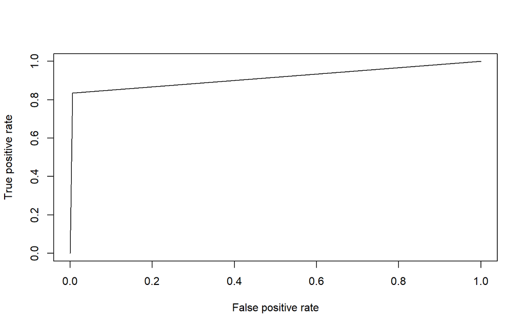

```r
predRF <- prediction(as.numeric(pred.valid.RF), as.numeric(estrellas.test$target_class))
perfRF <- performance(predRF, "tpr", "fpr")
plot(perfRF)
```

```r
auc.pRF<-performance(predRF,"auc")
```

### d. Regresión Logística

```r
logistic_regression <- glm(target_class ~ ., family = binomial, data = estrellas.train)
summary(logistic_regression)
```

```
##
## Call:
## glm(formula = target_class ~ ., family = binomial, data = estrellas.train)
##
## Deviance Residuals:
##     Min       1Q   Median       3Q      Max
## -4.0742  -0.1616  -0.0984  -0.0554   3.6170
##
## Coefficients:
##                                               Estimate Std. Error z value
## (Intercept)                                  -9.303447   1.097926  -8.474
## Mean.of.the.integrated.profile                0.033033   0.006657   4.962
## Standard.deviation.of.the.integrated.profile -0.035899   0.011721  -3.063
## Excess.kurtosis.of.the.integrated.profile     6.735043   0.339455  19.841
## Skewness.of.the.integrated.profile           -0.625156   0.047190 -13.248
## Mean.of.the.DM.SNR.curve                     -0.027278   0.003631  -7.514
## Standard.deviation.of.the.DM.SNR.curve        0.050369   0.008213   6.133
## Excess.kurtosis.of.the.DM.SNR.curve           0.052821   0.094402   0.560
## Skewness.of.the.DM.SNR.curve                 -0.005325   0.003336  -1.596
##                                              Pr(>|z|)
## (Intercept)                                   < 2e-16 ***
## Mean.of.the.integrated.profile               6.98e-07 ***
## Standard.deviation.of.the.integrated.profile  0.00219 **
## Excess.kurtosis.of.the.integrated.profile     < 2e-16 ***
## Skewness.of.the.integrated.profile            < 2e-16 ***
## Mean.of.the.DM.SNR.curve                     5.76e-14 ***
## Standard.deviation.of.the.DM.SNR.curve       8.61e-10 ***
## Excess.kurtosis.of.the.DM.SNR.curve           0.57580
## Skewness.of.the.DM.SNR.curve                  0.11045
## ---
## Signif. codes:  0 '***' 0.001 '**' 0.01 '*' 0.05 '.' 0.1 ' ' 1
##
## (Dispersion parameter for binomial family taken to be 1)
##
##     Null deviance: 8771.6  on 14319  degrees of freedom
## Residual deviance: 2058.5  on 14311  degrees of freedom
## AIC: 2076.5
##
## Number of Fisher Scoring iterations: 8
```

```r
pred.train <- predict(logistic_regression, type = 'response', ndata = estrellas.train)
pred.train <- ifelse(pred.train > 0.5, 1, 0)
pred.train <- factor(pred.train, levels = c("0", "1"), labels = c("No pulsar", "pulsar"))
```

Matriz de confusión para regresión logística

```r
matrizConfusionTRL <- table(estrellas.train$target_class, pred.train)
matrizConfusionTRL
```

```
##    pred.train
##     No pulsar pulsar
##   0     12940     68
##   1       223   1089
```

Aplicado al conjunto de pruebas

```r
pred.valid <- predict(logistic_regression, type = 'response', newdata = estrellas.test)
pred.valid <- ifelse(pred.valid > 0.5, 1, 0)
pred.valid <- factor(pred.valid, levels = c("0", "1"), labels = c("No pulsar", "pulsar"))
matrizConfusionPRL <- table(test.set$target_class, pred.valid)
matrizConfusionPRL
```

```
##    pred.valid
##     No pulsar pulsar
##   0      3233     18
##   1        61    266
```

Curva ROC para la regresión logística.

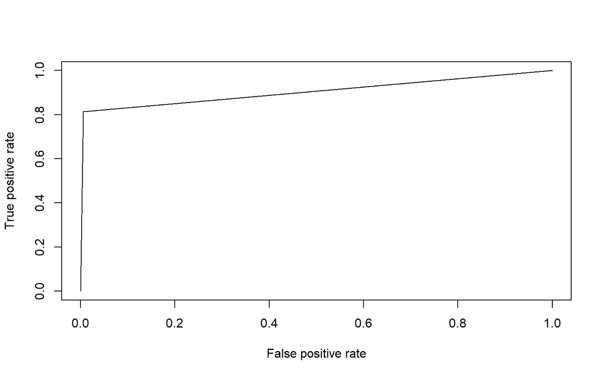

```r
pred1 <- prediction(as.numeric(pred.valid), as.numeric(estrellas.test$target_class))
perf1 <- performance(pred1, "tpr", "fpr")
plot(perf1)
```

```r
auc.prl<-performance(pred1,"auc")
```

```r
indicadores.calidad(matrizConfusionPRL)
```

```
##   Precision.Global Error.Global Precision.Positiva Precision.Negativa
## 1        0.9779206   0.02207937          0.8134557          0.9944632
##   Falsos.Positivos Falsos.Negativos Asertividad.Positiva
## 1        0.1865443      0.005536758            0.9366197
##   Asertividad.Negatividad
## 1               0.9814815
```

## 4. ¿Cuál modelo es mejor? Justifique su respuesta.

```r
precision<-c((matrizConfusionTRL[1,1] + matrizConfusionTRL[2,2])/sum(matrizConfusionTRL),
            (matrizConfusionBayes[1,1] + matrizConfusionBayes[2,2])/sum(matrizConfusionBayes),
            (matrizConfusionDT[1,1] + matrizConfusionDT[2,2])/sum(matrizConfusionDT),
            (matrizConfusionRF[1,1] + matrizConfusionRF[2,2])/sum(matrizConfusionRF),
            (matrizConfusionSVM[1,1] + matrizConfusionSVM[2,2])/sum(matrizConfusionSVM)
             )
curva.ROC<-c(auc.prl@y.values[[1]],
             auc.pBayes@y.values[[1]],
             auc.pDT@y.values[[1]],
             auc.pRF@y.values[[1]],
             auc.pSVM@y.values[[1]])

resultados<-data.frame(
  Precisión = precision,
  Error = 1-precision,
  ROC = curva.ROC
)

row.names(resultados)<-c("Regresión Logística","Bayes","Árboles","Bosques","Máquinas")

DT:::datatable(resultados)%>%
            formatPercentage(colnames(resultados),2)
```

|  | Precisión | Error | ROC |
| --- | --- | --- | --- |
| Regresión Logística | 0.979678770949721 | 0.0203212290502793 | 0.903959449785858 |
| Bayes | 0.94242593627725 | 0.0575740637227501 | 0.902305289268792 |
| Árboles | 0.975405254332029 | 0.0245947456679709 | 0.902575260305697 |
| Bosques | 0.979597540525433 | 0.0204024594745668 | 0.914509014869102 |
| Máquinas | 0.977361654555618 | 0.0226383454443824 | 0.901055144641451 |

## 5. Realice 20 veces la calibración de estos modelos (utilizar el código visto en clases)

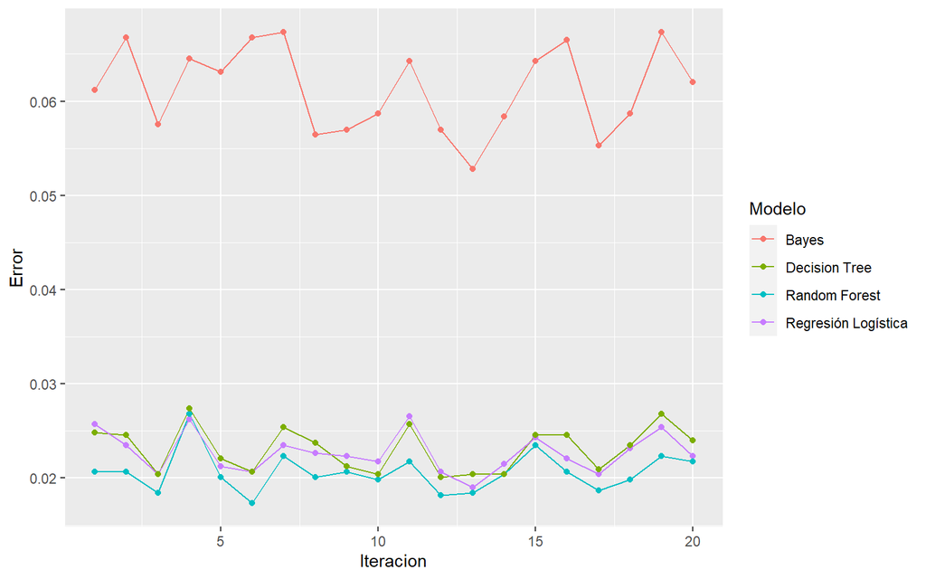

```r
num.iter<-20
promedio_error_logistica <- 0
promedio_error_randomForest <- 0
promedio_error_arboles <- 0
promedio_error_bayes <- 0

vector_log <- c()
vector_randomForest <- c()
vector_arboles <- c()
vector_bayes <- c()

Error.df<-data.frame(Modelo = c() , Iteracion = c() , Error = c())
N<-dim(estrellas)[1]
muestra.tam<-floor(dim(estrellas)[1]*0.8)
for(i in 1:num.iter)
{
  set.seed(set.seed(1234))
  muestra <- sample(1:N,size = muestra.tam)
  estrellas.train <- estrellas[muestra,-c(1,4,8) ]
  estrellas.test  <- estrellas[-muestra, -c(1,4,8)]

  ##Logistico
  names(estrellas.train) <- make.names(names(estrellas.train))
  names(estrellas.test) <- make.names(names(estrellas.test))

  RL <- glm(target_class ~ ., family = binomial, data = estrellas.train)
  pred.valid <- predict(RL, type = 'response', newdata = estrellas.test)
  pred.valid <- ifelse(pred.valid > 0.5, 1, 0)
  pred.valid <- factor(pred.valid, levels = c("0", "1"), labels = c("No pulsar", "Pulsar"))
  matrizConfusionPRL <- table(estrellas.test$target_class, pred.valid)
  tmp.ind.log<-indicadores.calidad(matrizConfusionPRL)

  tmp.df<-data.frame(Modelo = "Regresión Logística", Iteracion = i,Error = tmp.ind.log$Error.Global)
  Error.df<-rbind(Error.df,tmp.df)

  promedio_error_logistica = promedio_error_logistica + tmp.ind.log$Error.Global

  vector_log <- c(vector_log, tmp.ind.log$Error.Global)

  ##Random forest
  clasificadorRF <- randomForest(target_class ~ ., data = estrellas.train, ntree = 250)
  pred.valid.RF <- predict(clasificadorRF, newdata = estrellas.test)
  matrizConfusionRF <- table(estrellas.test$target_class, pred.valid.RF)
  tmp.ind.forest <- indicadores.calidad(matrizConfusionRF)

  tmp.df<-data.frame(Modelo = "Random Forest", Iteracion = i,Error = tmp.ind.forest$Error.Global)
  Error.df<-rbind(Error.df,tmp.df)

  promedio_error_randomForest <- promedio_error_randomForest + tmp.ind.forest$Error.Global

  vector_randomForest <- c(vector_randomForest, tmp.ind.forest$Error.Global)

  #Arboles de decision
  clasificadorDT <- rpart(target_class ~ ., data = estrellas.train)
  pred.valid.DT <- predict(clasificadorDT, newdata = estrellas.test, type = 'class')
  matrizConfusionDT <- table(estrellas.test$target_class, pred.valid.DT)
  tmp.ind.dthree <- indicadores.calidad(matrizConfusionDT)

  tmp.df<-data.frame(Modelo = "Decision Tree", Iteracion = i,Error = tmp.ind.dthree$Error.Global)
  Error.df<-rbind(Error.df,tmp.df)

  promedio_error_arboles <- promedio_error_arboles + tmp.ind.dthree$Error.Global

  vector_arboles <- c(vector_arboles,tmp.ind.dthree$Error.Global)

  #Bayes
  clasificadorBayes <- naiveBayes(target_class ~ ., data = estrellas.train)
  pred.valid.bayes <- predict(clasificadorBayes, newdata = estrellas.test)
  matrizConfusionBayes <- table(estrellas.test$target_class, pred.valid.bayes)
  tmp.ind.bayes <- indicadores.calidad(matrizConfusionBayes)

  sd(tmp.ind.bayes$Error.Global)

  tmp.df<-data.frame(Modelo = "Bayes", Iteracion = i,Error = tmp.ind.bayes$Error.Global)
  Error.df<-rbind(Error.df,tmp.df)

  promedio_error_bayes <- promedio_error_bayes + tmp.ind.bayes$Error.Global

  vector_bayes <- c(vector_bayes,tmp.ind.bayes$Error.Global)

}

p<-ggplot(Error.df, aes(x=Iteracion, y=Error, group=Modelo)) +
  geom_line(aes(color=Modelo))+
  geom_point(aes(color=Modelo))
p
```

### a. Calcule el promedio de error

```r
print(paste0("Promedio de error regresión lógistica: ", promedio_error_logistica/20))
```

```
## [1] "Promedio de error regresión lógistica: 0.0226675977653631"
```

```r
print(paste0("Promedio de error regresión Random Forest: ", promedio_error_randomForest/20))
```

```
## [1] "Promedio de error regresión Random Forest: 0.0206284916201117"
```

```r
print(paste0("Promedio de error regresión Arboles de Decision: ", promedio_error_arboles/20))
```

```
## [1] "Promedio de error regresión Arboles de Decision: 0.023086592178771"
```

```r
print(paste0("Promedio de error regresión Bayes: ", promedio_error_bayes/20))
```

```
## [1] "Promedio de error regresión Bayes: 0.0612849162011173"
```

### b. Calcule la desviación estándar

```r
print(paste0("La desviación estandar de error regresión lógistica: ", sd(x=vector_log)))
```

```
## [1] "La desviación estandar de error regresión lógistica: 0.00212010795475999"
```

```r
print(paste0("La desviación estandar de error Random Forest: ", sd(x=vector_randomForest)))
```

```
## [1] "La desviación estandar de error Random Forest: 0.00214130859801038"
```

```r
print(paste0("La desviación estandar de error Arboles de decisión: ", sd(x=vector_arboles)))
```

```
## [1] "La desviación estandar de error Arboles de decisión: 0.00239136336499059"
```

```r
print(paste0("La desviación estandar de error Bayes: ", sd(x=vector_bayes)))
```

```
## [1] "La desviación estandar de error Bayes: 0.00456779098175783"
```

### c. ¿Cuál modelo es mejor? Justifique su respuesta

El modelo que mejor califica está entre el Random Forest y el logístico, teniendo en cuenta dos parámetros de suma importancia. En primer lugar, la precisión, donde el logístico cuenta una precisión de 97.97% y el de Bosques es de 97.96%, siendo estos dos los más precisos. En error los separa una décimal, donde el logístico tiene un error de 2.03% y el de bosques 2.04%. Sin embargo, como vimos anteriormente, en promedio de error con la calibración (20 iteraciones) es menor. Por lo tanto, el mejor modelo es el Random Forest.

### d. El modelo seleccionado en el punto 3 es el mismo que en el punto 4.

Si, es el mismo.

# Ejercicio 2 (35 puntos).

```r
library(mlbench)
data(PimaIndiansDiabetes2)
```

```r
DT::datatable(PimaIndiansDiabetes2)
```

|  | pregnant | glucose | pressure | triceps | insulin | mass | pedigree | age | diabetes |
| --- | --- | --- | --- | --- | --- | --- | --- | --- | --- |
| 1 | 6 | 148 | 72 | 35 |  | 33.6 | 0.627 | 50 | pos |
| 2 | 1 | 85 | 66 | 29 |  | 26.6 | 0.351 | 31 | neg |
| 3 | 8 | 183 | 64 |  |  | 23.3 | 0.672 | 32 | pos |
| 4 | 1 | 89 | 66 | 23 | 94 | 28.1 | 0.167 | 21 | neg |
| 5 | 0 | 137 | 40 | 35 | 168 | 43.1 | 2.288 | 33 | pos |
| 6 | 5 | 116 | 74 |  |  | 25.6 | 0.201 | 30 | neg |
| 7 | 3 | 78 | 50 | 32 | 88 | 31 | 0.248 | 26 | pos |
| 8 | 10 | 115 |  |  |  | 35.3 | 0.134 | 29 | neg |
| 9 | 2 | 197 | 70 | 45 | 543 | 30.5 | 0.158 | 53 | pos |
| 10 | 8 | 125 | 96 |  |  |  | 0.232 | 54 | pos |

[output cut: 758 more lines]

NA -> 0

```r
PimaIndiansDiabetes2[is.na(PimaIndiansDiabetes2)] <- 0
map_dbl(PimaIndiansDiabetes2, .f = function(x){sum(is.na(x))})
```

```
## pregnant  glucose pressure  triceps  insulin     mass pedigree      age
##        0        0        0        0        0        0        0        0
## diabetes
##        0
```

```r
PimaIndiansDiabetes2$diabetes <- as.factor(PimaIndiansDiabetes2$diabetes)
```

Distribución de la variable respuesta.

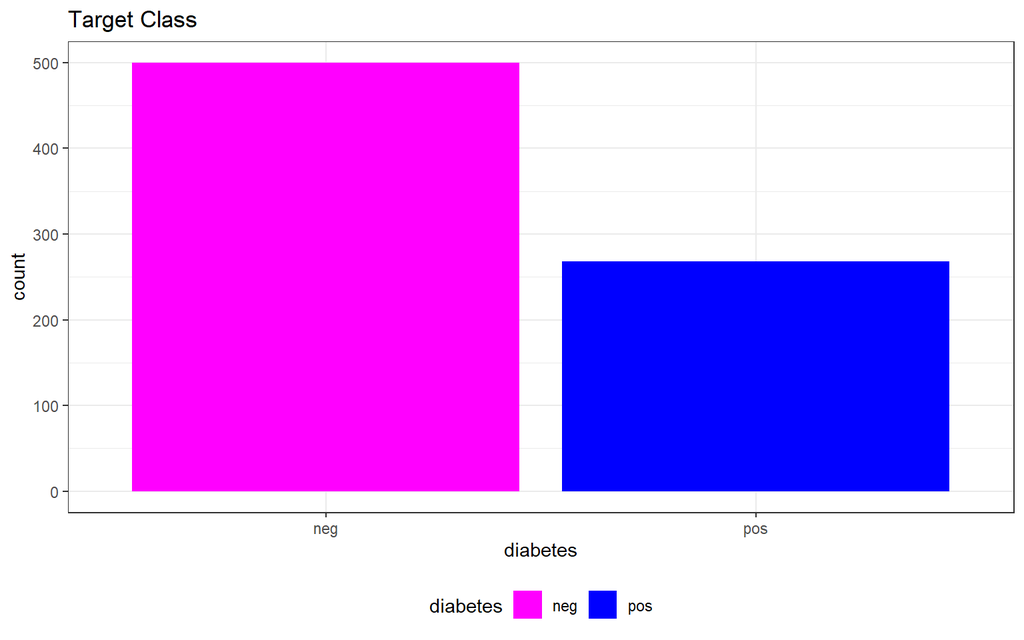

```r
ggplot(data = PimaIndiansDiabetes2, aes(x = diabetes, y = ..count.., fill = diabetes )) +
  geom_bar() +
  scale_fill_manual(values = c("magenta", "blue")) +
  labs(title = "Target Class") +
  theme_bw() +
  theme(legend.position = "bottom")
```

Cantidad en porcentajes

```r
tmp<-table(PimaIndiansDiabetes2$diabetes)
df<-as.data.frame(tmp)
colnames(df)<-c("class","Cantidad")
df$Porcentaje<-df$Cantidad/sum(df$Cantidad)
DT:::datatable(df)%>%formatPercentage("Porcentaje",2)
```

|  | class | Cantidad | Porcentaje |
| --- | --- | --- | --- |
| 1 | neg | 500 | 0.651041666666667 |
| 2 | pos | 268 | 0.348958333333333 |

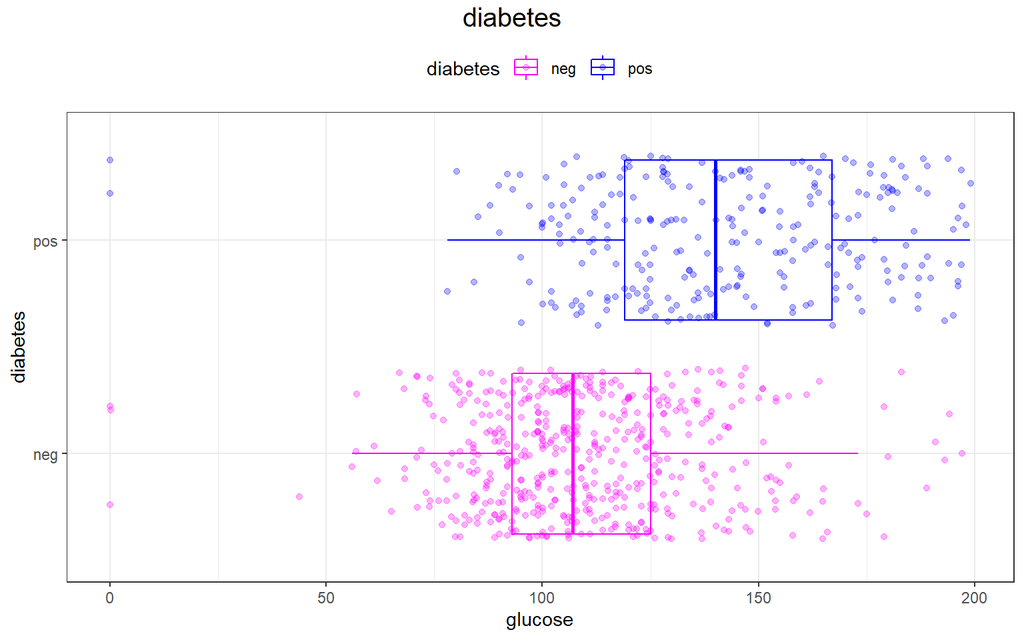

```r
p2 <- ggplot(data = PimaIndiansDiabetes2, aes(x = glucose, y = diabetes, color = diabetes)) +
      geom_boxplot(outlier.shape = NA) +
      geom_jitter(alpha = 0.3, width = 0.15) +
      scale_color_manual(values = c("magenta", "blue")) +
      theme_bw()
final.plot <- ggarrange(p2, legend = "top")
final.plot <- annotate_figure(final.plot, top = text_grob("diabetes", size = 15))
final.plot
```

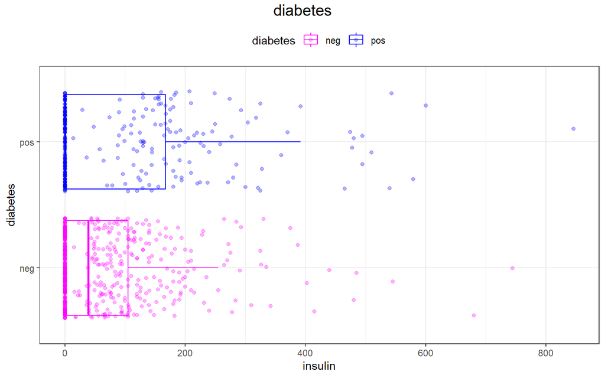

```r
p2 <- ggplot(data = PimaIndiansDiabetes2, aes(x = insulin, y = diabetes, color = diabetes)) +
      geom_boxplot(outlier.shape = NA) +
      geom_jitter(alpha = 0.3, width = 0.15) +
      scale_color_manual(values = c("magenta", "blue")) +
      theme_bw()
final.plot <- ggarrange(p2, legend = "top")
final.plot <- annotate_figure(final.plot, top = text_grob("diabetes", size = 15))
final.plot
```

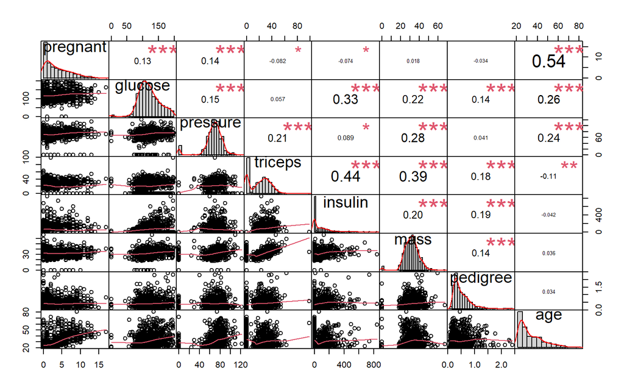

```r
chart.Correlation(PimaIndiansDiabetes2[,1:8], histogram = TRUE, method = "pearson")
```

Realice lo siguiente:

## 1. Cree dos datasets:

1. 80% de los datos para training
2. 20% para testing

```r
set.seed(123)
# Se crean los índices de las observaciones de entrenamiento
train <- createDataPartition(y = PimaIndiansDiabetes2$diabetes, p = 0.8, list = FALSE, times = 1)
PimaIndiansDiabetes2.train <- PimaIndiansDiabetes2[train, ]
PimaIndiansDiabetes2.test  <- PimaIndiansDiabetes2[-train, ]
```

```r
pro.train<-as.data.frame(table(PimaIndiansDiabetes2.train$diabetes))
pro.test<-as.data.frame(table(PimaIndiansDiabetes2.test$diabetes))

colnames(pro.train)<-c("diabetes","Q.train")

pro.train$Q.test<-pro.test$Freq

pro.train$Porc.train<-pro.train$Q.train/sum(pro.train$Q.train)
pro.train$Porc.test<-pro.train$Q.test/sum(pro.train$Q.test)

DT::datatable(pro.train)%>%formatPercentage(c("Porc.train","Porc.test"),2)
```

|  | diabetes | Q.train | Q.test | Porc.train | Porc.test |
| --- | --- | --- | --- | --- | --- |
| 1 | neg | 400 | 100 | 0.650406504065041 | 0.65359477124183 |
| 2 | pos | 215 | 53 | 0.349593495934959 | 0.34640522875817 |

```r
objeto.recipe <- recipe(formula = diabetes ~ pregnant + glucose + pressure + triceps + insulin + mass + pedigree + age, data =  PimaIndiansDiabetes2.train)
objeto.recipe
```

```
## Recipe
##
## Inputs:
##
##       role #variables
##    outcome          1
##  predictor          8
```

```r
tmp<-PimaIndiansDiabetes2%>% dplyr::select(pregnant, glucose, pressure, triceps, insulin, mass, pedigree, age) %>%
          nearZeroVar(saveMetrics = TRUE)

DT::datatable(tmp)%>%formatPercentage("percentUnique",2)%>%formatRound("freqRatio",2)
```

|  | freqRatio | percentUnique | zeroVar | nzv |
| --- | --- | --- | --- | --- |
| pregnant | 1.21621621621622 | 2.21354166666667 | False | False |
| glucose | 1 | 17.7083333333333 | False | False |
| pressure | 1.09615384615385 | 6.11979166666667 | False | False |
| triceps | 7.32258064516129 | 6.640625 | False | False |
| insulin | 34 | 24.21875 | False | False |
| mass | 1.08333333333333 | 32.2916666666667 | False | False |
| pedigree | 1 | 67.3177083333333 | False | False |
| age | 1.14285714285714 | 6.77083333333333 | False | False |

```r
objeto.recipe <- objeto.recipe %>% step_nzv(all_predictors())
objeto.recipe <- objeto.recipe %>% step_nzv(all_predictors())
objeto.recipe <- objeto.recipe %>% step_center(all_numeric())
objeto.recipe <- objeto.recipe %>% step_scale(all_numeric())
objeto.recipe <- objeto.recipe %>% step_dummy(all_nominal(), -all_outcomes())
trained.recipe <- prep(objeto.recipe, training = PimaIndiansDiabetes2.train)
```

```r
training.set<-PimaIndiansDiabetes2.train.prep <- bake(trained.recipe, new_data = PimaIndiansDiabetes2.train)
test.set<-PimaIndiansDiabetes2.test.prep  <- bake(trained.recipe, new_data = PimaIndiansDiabetes2.test)
training.set<-as.data.frame(training.set)
test.set<-as.data.frame(test.set)
glimpse(PimaIndiansDiabetes2.train.prep)
```

```
## Rows: 615
## Columns: 9
## $ pregnant <dbl> 0.65335218, 1.24818799, -0.83373735, 0.35593427, -0.23890154,~
## $ glucose  <dbl> 0.84101105, 1.93828119, -1.00867291, -0.16220737, -1.35352924~
## $ pressure <dbl> 0.15930548, -0.24325382, -0.14261400, 0.25994531, -0.94773260~
## $ triceps  <dbl> 0.90671119, -1.28177932, 0.15637159, -1.28177932, 0.71912629,~
## $ insulin  <dbl> -0.69108734, -0.69108734, 0.11712918, -0.69108734, 0.06554089~
## $ mass     <dbl> 0.1957289, -1.1231144, -0.5085078, -0.8286154, -0.1371830, 0.~
## $ pedigree <dbl> 0.50618759, 0.64943944, -0.95816465, -0.84992992, -0.70031132~
## $ age      <dbl> 1.40855839, -0.10559401, -1.03090936, -0.27383316, -0.6103114~
## $ diabetes <fct> pos, pos, neg, neg, pos, neg, pos, pos, neg, pos, neg, pos, p~
```

## 2. Seleccione el mejor núcleo para SVM (“linear”,“radial”,“polynomial”,“sigmoid”), para esto deben utilizar el siguiente código (Y es la variable a predecir):

Radial

```r
clasificadorSVM  <- e1071::svm(PimaIndiansDiabetes2.train$diabetes ~ ., data = PimaIndiansDiabetes2.train, type = 'C-classification', kernel = 'radial')
pred.valid.svm <- predict(clasificadorSVM, newdata = PimaIndiansDiabetes2.test)
```

Matriz de confusión para SVM Radial

```r
matrizConfusionSVM <- table(test.set$diabetes, pred.valid.svm)
matrizConfusionSVM
```

```
##      pred.valid.svm
##       neg pos
##   neg  88  12
##   pos  22  31
```

```r
indicadores.calidad(matrizConfusionSVM)
```

```
##   Precision.Global Error.Global Precision.Positiva Precision.Negativa
## 1        0.7777778    0.2222222          0.5849057               0.88
##   Falsos.Positivos Falsos.Negativos Asertividad.Positiva
## 1        0.4150943             0.12            0.7209302
##   Asertividad.Negatividad
## 1                     0.8
```

Lineal

```r
clasificadorSVM  <- e1071::svm(PimaIndiansDiabetes2.train$diabetes ~ ., data = PimaIndiansDiabetes2.train, type = 'C-classification', kernel = 'linear')
pred.valid.svm <- predict(clasificadorSVM, newdata = PimaIndiansDiabetes2.test)
```

Matriz de confusión para SVM Lineal

```r
matrizConfusionSVM <- table(test.set$diabetes, pred.valid.svm)
matrizConfusionSVM
```

```
##      pred.valid.svm
##       neg pos
##   neg  91   9
##   pos  21  32
```

```r
indicadores.calidad(matrizConfusionSVM)
```

```
##   Precision.Global Error.Global Precision.Positiva Precision.Negativa
## 1        0.8039216    0.1960784          0.6037736               0.91
##   Falsos.Positivos Falsos.Negativos Asertividad.Positiva
## 1        0.3962264             0.09            0.7804878
##   Asertividad.Negatividad
## 1                  0.8125
```

polynomial

```r
clasificadorSVM  <- e1071::svm(PimaIndiansDiabetes2.train$diabetes ~ ., data = PimaIndiansDiabetes2.train, type = 'C-classification', kernel = 'polynomial')
pred.valid.svm <- predict(clasificadorSVM, newdata = PimaIndiansDiabetes2.test)
```

Matriz de confusión para SVM polynomial

```r
matrizConfusionSVM <- table(test.set$diabetes, pred.valid.svm)
matrizConfusionSVM
```

```
##      pred.valid.svm
##       neg pos
##   neg  95   5
##   pos  30  23
```

```r
indicadores.calidad(matrizConfusionSVM)
```

```
##   Precision.Global Error.Global Precision.Positiva Precision.Negativa
## 1        0.7712418    0.2287582          0.4339623               0.95
##   Falsos.Positivos Falsos.Negativos Asertividad.Positiva
## 1        0.5660377             0.05            0.8214286
##   Asertividad.Negatividad
## 1                    0.76
```

sigmoid

```r
clasificadorSVM  <- e1071::svm(PimaIndiansDiabetes2.train$diabetes ~ ., data = PimaIndiansDiabetes2.train, type = 'C-classification', kernel = 'sigmoid')
pred.valid.svm <- predict(clasificadorSVM, newdata = PimaIndiansDiabetes2.test)
```

Matriz de confusión para SVM sigmoid

```r
matrizConfusionSVM <- table(test.set$diabetes, pred.valid.svm)
matrizConfusionSVM
```

```
##      pred.valid.svm
##       neg pos
##   neg  83  17
##   pos  23  30
```

```r
indicadores.calidad(matrizConfusionSVM)
```

```
##   Precision.Global Error.Global Precision.Positiva Precision.Negativa
## 1        0.7385621    0.2614379          0.5660377               0.83
##   Falsos.Positivos Falsos.Negativos Asertividad.Positiva
## 1        0.4339623             0.17            0.6382979
##   Asertividad.Negatividad
## 1               0.7830189
```

En este caso la que mejor califica es el lineal.

## 3. Entrene los demás modelos:

### a. Bayes

```r
set.seed(1234)
clasificadorBayes <- naiveBayes(diabetes ~ ., data = PimaIndiansDiabetes2.train)
```

Prediccion en el conjunto de validaciones.

```r
pred.valid.bayes <- predict(clasificadorBayes, newdata = PimaIndiansDiabetes2.test)
```

Matriz de confusión de Bayes.

```r
matrizConfusionBayes <- table(PimaIndiansDiabetes2.test$diabetes, pred.valid.bayes)
matrizConfusionBayes
```

```
##      pred.valid.bayes
##       neg pos
##   neg  85  15
##   pos  15  38
```

```r
indicadores.calidad(matrizConfusionBayes)
```

```
##   Precision.Global Error.Global Precision.Positiva Precision.Negativa
## 1        0.8039216    0.1960784          0.7169811               0.85
##   Falsos.Positivos Falsos.Negativos Asertividad.Positiva
## 1        0.2830189             0.15            0.7169811
##   Asertividad.Negatividad
## 1                    0.85
```

Curva ROC para bayes

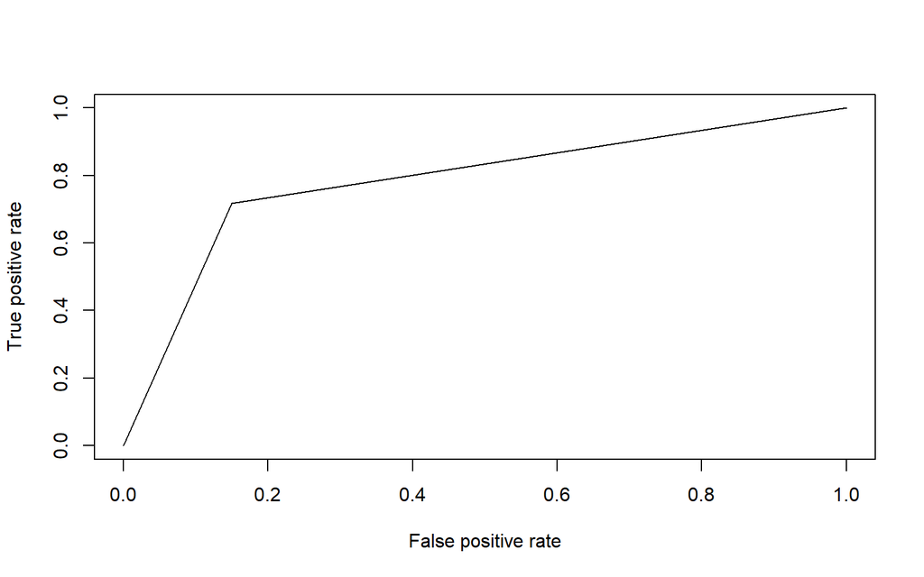

```r
predBayes <- prediction(as.numeric(pred.valid.bayes), as.numeric(test.set$diabetes))
perfBayes <- performance(predBayes, "tpr", "fpr")
plot(perfBayes)
```

### b. Arboles

```r
set.seed(1234)
clasificadorDT <- rpart(diabetes ~ ., data = PimaIndiansDiabetes2.train)
pred.valid.DT <- predict(clasificadorDT, newdata = PimaIndiansDiabetes2.test, type = 'class')
matrizConfusionDT <- table(PimaIndiansDiabetes2.test$diabetes, pred.valid.DT)
matrizConfusionDT
```

```
##      pred.valid.DT
##       neg pos
##   neg  86  14
##   pos  23  30
```

Indicadores de calidad para Arboles

```r
indicadores.calidad(matrizConfusionDT)
```

```
##   Precision.Global Error.Global Precision.Positiva Precision.Negativa
## 1        0.7581699    0.2418301          0.5660377               0.86
##   Falsos.Positivos Falsos.Negativos Asertividad.Positiva
## 1        0.4339623             0.14            0.6818182
##   Asertividad.Negatividad
## 1               0.7889908
```

Curva ROC para arboles

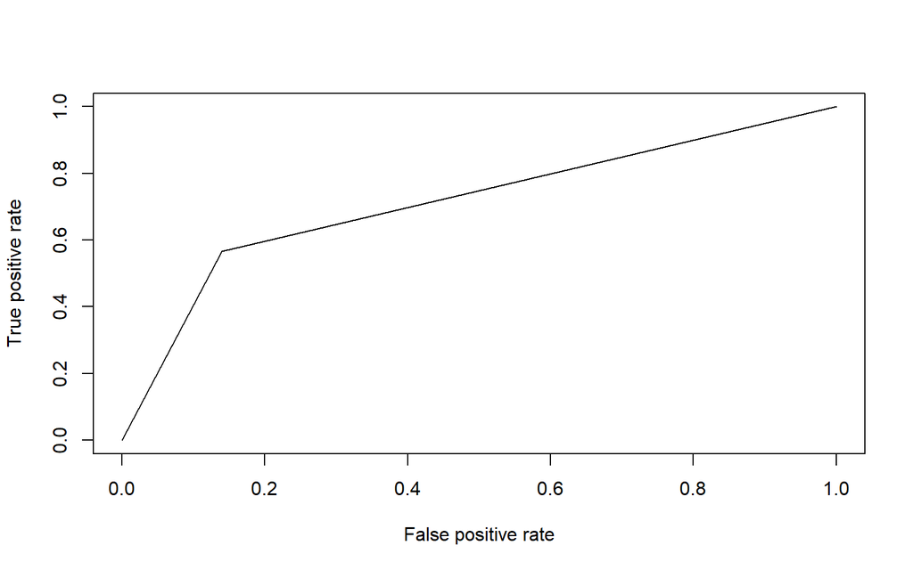

```r
predDT <- prediction(as.numeric(pred.valid.DT), as.numeric(PimaIndiansDiabetes2.test$diabetes))
perfDT <- performance(predDT, "tpr", "fpr")
plot(perfDT)
```

## c. Bosques Aleatorios

```r
names(PimaIndiansDiabetes2.train) <- make.names(names(PimaIndiansDiabetes2.train))
names(PimaIndiansDiabetes2.test) <- make.names(names(PimaIndiansDiabetes2.test))
clasificadorRF <- randomForest(diabetes ~ ., data = PimaIndiansDiabetes2.train, ntree = 250)
ed.valid.RF <- predict(clasificadorRF, newdata = PimaIndiansDiabetes2.test)
pred.valid.RF <- predict(clasificadorRF, newdata = PimaIndiansDiabetes2.test)
```

Matriz de confusión de Random Forest.

```r
matrizConfusionRF <- table(PimaIndiansDiabetes2.test$diabetes, pred.valid.RF)
matrizConfusionRF
```

```
##      pred.valid.RF
##       neg pos
##   neg  89  11
##   pos  20  33
```

Indicadores de calidad para random Forest

```r
indicadores.calidad(matrizConfusionRF)
```

```
##   Precision.Global Error.Global Precision.Positiva Precision.Negativa
## 1        0.7973856    0.2026144          0.6226415               0.89
##   Falsos.Positivos Falsos.Negativos Asertividad.Positiva
## 1        0.3773585             0.11                 0.75
##   Asertividad.Negatividad
## 1               0.8165138
```

Curva ROC para Random Forest

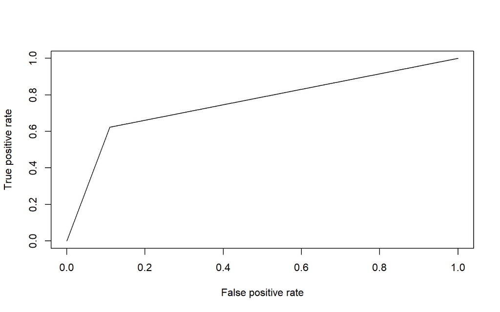

```r
predRF <- prediction(as.numeric(pred.valid.RF), as.numeric(PimaIndiansDiabetes2.test$diabetes))
perfRF <- performance(predRF, "tpr", "fpr")
plot(perfRF)
```

## d. Regresión Logística

```r
logistic_regression <- glm(diabetes ~ ., family = binomial, data = PimaIndiansDiabetes2.train)
summary(logistic_regression)
```

```
##
## Call:
## glm(formula = diabetes ~ ., family = binomial, data = PimaIndiansDiabetes2.train)
##
## Deviance Residuals:
##     Min       1Q   Median       3Q      Max
## -2.4719  -0.7674  -0.4402   0.7776   2.9436
##
## Coefficients:
##               Estimate Std. Error z value Pr(>|z|)
## (Intercept) -7.8116450  0.7694301 -10.153  < 2e-16 ***
## pregnant     0.0998300  0.0358381   2.786  0.00534 **
## glucose      0.0342306  0.0040533   8.445  < 2e-16 ***
## pressure    -0.0148671  0.0055567  -2.676  0.00746 **
## triceps     -0.0006103  0.0076247  -0.080  0.93621
## insulin     -0.0007117  0.0009565  -0.744  0.45681
## mass         0.0806695  0.0165458   4.876 1.09e-06 ***
## pedigree     0.9355556  0.3388561   2.761  0.00576 **
## age          0.0154356  0.0102718   1.503  0.13291
## ---
## Signif. codes:  0 '***' 0.001 '**' 0.01 '*' 0.05 '.' 0.1 ' ' 1
##
## (Dispersion parameter for binomial family taken to be 1)
##
##     Null deviance: 796.05  on 614  degrees of freedom
## Residual deviance: 598.41  on 606  degrees of freedom
## AIC: 616.41
##
## Number of Fisher Scoring iterations: 5
```

```r
pred.train <- predict(logistic_regression, type = 'response', ndata = PimaIndiansDiabetes2.train)
pred.train <- ifelse(pred.train > 0.5, 1, 0)
#PimaIndiansDiabetes2$diabetes<-ifelse(PimaIndiansDiabetes2$diabetes=="pos",1,0)
pred.train <- factor(pred.train, levels = c("1", "0"), labels = c("positivo", "negativo"))
```

Matriz de confusión para regresión logística

```r
matrizConfusionTRL <- table(PimaIndiansDiabetes2.train$diabetes, pred.train)
matrizConfusionTRL
```

```
##      pred.train
##       positivo negativo
##   neg       44      356
##   pos      123       92
```

```r
indicadores.calidad(matrizConfusionPRL)
```

[output not shown]

## 4. ¿Cuál es el mejor modelo? Justifica su respuesta.

```r
precision<-c((matrizConfusionTRL[1,1] + matrizConfusionTRL[2,2])/sum(matrizConfusionTRL),
            (matrizConfusionBayes[1,1] + matrizConfusionBayes[2,2])/sum(matrizConfusionBayes),
            (matrizConfusionDT[1,1] + matrizConfusionDT[2,2])/sum(matrizConfusionDT),
            (matrizConfusionRF[1,1] + matrizConfusionRF[2,2])/sum(matrizConfusionRF),
            (matrizConfusionSVM[1,1] + matrizConfusionSVM[2,2])/sum(matrizConfusionSVM)
             )
curva.ROC<-c(auc.prl@y.values[[1]],
             auc.pBayes@y.values[[1]],
             auc.pDT@y.values[[1]],
             auc.pRF@y.values[[1]],
             auc.pSVM@y.values[[1]])

resultados<-data.frame(
  Precisión = precision,
  Error = 1-precision,
  ROC = curva.ROC
)

row.names(resultados)<-c("Regresión Logística","Bayes","Árboles","Bosques","Máquinas")

DT:::datatable(resultados)%>%
            formatPercentage(colnames(resultados),2)
```

|  | Precisión | Error | ROC |
| --- | --- | --- | --- |
| Regresión Logística | 0.221138211382114 | 0.778861788617886 | 0.903959449785858 |
| Bayes | 0.803921568627451 | 0.196078431372549 | 0.902305289268792 |
| Árboles | 0.758169934640523 | 0.241830065359477 | 0.902575260305697 |
| Bosques | 0.797385620915033 | 0.202614379084967 | 0.914509014869102 |
| Máquinas | 0.738562091503268 | 0.261437908496732 | 0.901055144641451 |

En este análisis, el algoritmo de Bayes es el que mejores indicadores tiene. Tanto en precisión global como en error.

## 5. Realice 20 veces la calibración de estos modelos (utilizar el código visto en clases)

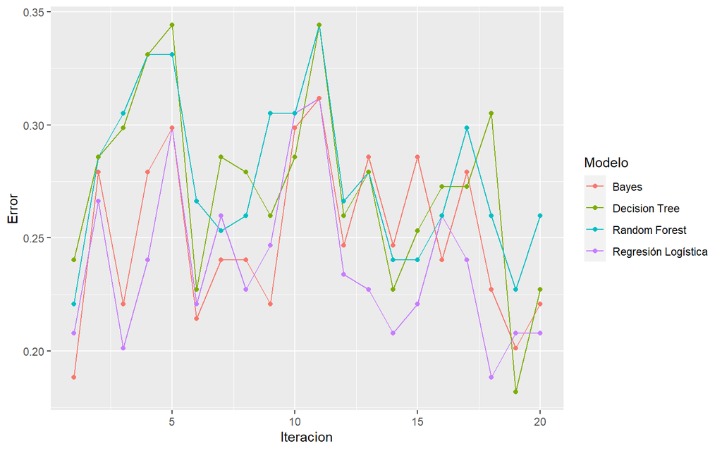

```r
num.iter<-20
promedio_error_logistica <- 0
promedio_error_randomForest <- 0
promedio_error_arboles <- 0
promedio_error_bayes <- 0

vector_log <- c()
vector_randomForest <- c()
vector_arboles <- c()
vector_bayes <- c()

Error.df<-data.frame(Modelo = c() , Iteracion = c() , Error = c())
N<-dim(PimaIndiansDiabetes2)[1]
muestra.tam<-floor(dim(PimaIndiansDiabetes2)[1]*0.8)
for(i in 1:num.iter)
{
  set.seed(set.seed(1234))
  muestra <- sample(1:N,size = muestra.tam)
  PimaIndiansDiabetes2.train <- PimaIndiansDiabetes2[muestra,-c(1,4,8) ]
  PimaIndiansDiabetes2.test  <- PimaIndiansDiabetes2[-muestra, -c(1,4,8)]

  ##Logistico
  names(PimaIndiansDiabetes2.train) <- make.names(names(PimaIndiansDiabetes2.train))
  names(PimaIndiansDiabetes2.test) <- make.names(names(PimaIndiansDiabetes2.test))

  RL <- glm(diabetes ~ ., family = binomial, data = PimaIndiansDiabetes2.train)
  pred.valid <- predict(RL, type = 'response', newdata = PimaIndiansDiabetes2.test)
  pred.valid <- ifelse(pred.valid > 0.5, 1, 0)
  pred.valid <- factor(pred.valid, levels = c("0", "1"), labels = c("No pulsar", "Pulsar"))
  matrizConfusionPRL <- table(PimaIndiansDiabetes2.test$diabetes, pred.valid)
  tmp.ind.log<-indicadores.calidad(matrizConfusionPRL)

  tmp.df<-data.frame(Modelo = "Regresión Logística", Iteracion = i,Error = tmp.ind.log$Error.Global)
  Error.df<-rbind(Error.df,tmp.df)

  promedio_error_logistica = promedio_error_logistica + tmp.ind.log$Error.Global

  vector_log <- c(vector_log, tmp.ind.log$Error.Global)

  ##Random forest
  clasificadorRF <- randomForest(diabetes ~ ., data = PimaIndiansDiabetes2.train, ntree = 250)
  pred.valid.RF <- predict(clasificadorRF, newdata = PimaIndiansDiabetes2.test)
  matrizConfusionRF <- table(PimaIndiansDiabetes2.test$diabetes, pred.valid.RF)
  tmp.ind.forest <- indicadores.calidad(matrizConfusionRF)

  tmp.df<-data.frame(Modelo = "Random Forest", Iteracion = i,Error = tmp.ind.forest$Error.Global)
  Error.df<-rbind(Error.df,tmp.df)

  promedio_error_randomForest <- promedio_error_randomForest + tmp.ind.forest$Error.Global

  vector_randomForest <- c(vector_randomForest, tmp.ind.forest$Error.Global)

  #Arboles de decision
  clasificadorDT <- rpart(diabetes ~ ., data = PimaIndiansDiabetes2.train)
  pred.valid.DT <- predict(clasificadorDT, newdata = PimaIndiansDiabetes2.test, type = 'class')
  matrizConfusionDT <- table(PimaIndiansDiabetes2.test$diabetes, pred.valid.DT)
  tmp.ind.dthree <- indicadores.calidad(matrizConfusionDT)

  tmp.df<-data.frame(Modelo = "Decision Tree", Iteracion = i,Error = tmp.ind.dthree$Error.Global)
  Error.df<-rbind(Error.df,tmp.df)

  promedio_error_arboles <- promedio_error_arboles + tmp.ind.dthree$Error.Global

  vector_arboles <- c(vector_arboles,tmp.ind.dthree$Error.Global)

  #Bayes
  clasificadorBayes <- naiveBayes(diabetes ~ ., data = PimaIndiansDiabetes2.train)
  pred.valid.bayes <- predict(clasificadorBayes, newdata = PimaIndiansDiabetes2.test)
  matrizConfusionBayes <- table(PimaIndiansDiabetes2.test$diabetes, pred.valid.bayes)
  tmp.ind.bayes <- indicadores.calidad(matrizConfusionBayes)

  sd(tmp.ind.bayes$Error.Global)

  tmp.df<-data.frame(Modelo = "Bayes", Iteracion = i,Error = tmp.ind.bayes$Error.Global)
  Error.df<-rbind(Error.df,tmp.df)

  promedio_error_bayes <- promedio_error_bayes + tmp.ind.bayes$Error.Global

  vector_bayes <- c(vector_bayes,tmp.ind.bayes$Error.Global)

}

p<-ggplot(Error.df, aes(x=Iteracion, y=Error, group=Modelo)) +
  geom_line(aes(color=Modelo))+
  geom_point(aes(color=Modelo))
p
```

### a. Calcule el promedio de error

```r
print(paste0("Promedio de error regresión lógistica: ", promedio_error_logistica/20))
```

```
## [1] "Promedio de error regresión lógistica: 0.238961038961039"
```

```r
print(paste0("Promedio de error regresión Random Forest: ", promedio_error_randomForest/20))
```

```
## [1] "Promedio de error regresión Random Forest: 0.276948051948052"
```

```r
print(paste0("Promedio de error regresión Arboles de Decision: ", promedio_error_arboles/20))
```

```
## [1] "Promedio de error regresión Arboles de Decision: 0.273051948051948"
```

```r
print(paste0("Promedio de error regresión Bayes: ", promedio_error_bayes/20))
```

```
## [1] "Promedio de error regresión Bayes: 0.251298701298701"
```

### b. Calcule la desviación estándar

```r
print(paste0("La desviación estandar de error regresión lógistica: ", sd(x=vector_log)))
```

```
## [1] "La desviación estandar de error regresión lógistica: 0.0353536128508426"
```

```r
print(paste0("La desviación estandar de error Random Forest: ", sd(x=vector_randomForest)))
```

```
## [1] "La desviación estandar de error Random Forest: 0.0352703408875069"
```

```r
print(paste0("La desviación estandar de error Arboles de decisión: ", sd(x=vector_arboles)))
```

```
## [1] "La desviación estandar de error Arboles de decisión: 0.0411481692373555"
```

```r
print(paste0("La desviación estandar de error Bayes: ", sd(x=vector_bayes)))
```

```
## [1] "La desviación estandar de error Bayes: 0.0358832144766871"
```

# Ejercicio 3 (30 puntos)

```r
datos <- titanic::titanic_train
DT::datatable(datos[1:10,])
```

|  | PassengerId | Survived | Pclass | Name | Sex | Age | SibSp | Parch | Ticket | Fare | Cabin | Embarked |
| --- | --- | --- | --- | --- | --- | --- | --- | --- | --- | --- | --- | --- |
| 1 | 1 | 0 | 3 | Braund, Mr. Owen Harris | male | 22 | 1 | 0 | A/5 21171 | 7.25 |  | S |
| 2 | 2 | 1 | 1 | Cumings, Mrs. John Bradley (Florence Briggs Thayer) | female | 38 | 1 | 0 | PC 17599 | 71.2833 | C85 | C |
| 3 | 3 | 1 | 3 | Heikkinen, Miss. Laina | female | 26 | 0 | 0 | STON/O2. 3101282 | 7.925 |  | S |
| 4 | 4 | 1 | 1 | Futrelle, Mrs. Jacques Heath (Lily May Peel) | female | 35 | 1 | 0 | 113803 | 53.1 | C123 | S |
| 5 | 5 | 0 | 3 | Allen, Mr. William Henry | male | 35 | 0 | 0 | 373450 | 8.05 |  | S |
| 6 | 6 | 0 | 3 | Moran, Mr. James | male |  | 0 | 0 | 330877 | 8.4583 |  | Q |
| 7 | 7 | 0 | 1 | McCarthy, Mr. Timothy J | male | 54 | 0 | 0 | 17463 | 51.8625 | E46 | S |
| 8 | 8 | 0 | 3 | Palsson, Master. Gosta Leonard | male | 2 | 3 | 1 | 349909 | 21.075 |  | S |
| 9 | 9 | 1 | 3 | Johnson, Mrs. Oscar W (Elisabeth Vilhelmina Berg) | female | 27 | 0 | 2 | 347742 | 11.1333 |  | S |
| 10 | 10 | 1 | 2 | Nasser, Mrs. Nicholas (Adele Achem) | female | 14 | 1 | 0 | 237736 | 30.0708 |  | C |

```r
datos$Survived <- if_else(datos$Survived == 1, "Si", "No")
datos$Survived <- as.factor(datos$Survived)
```

```r
datos$Pclass <- as.factor(datos$Pclass)
datos$SibSp <- as.factor(datos$SibSp)
datos$Parch <- as.factor(datos$Parch)
datos$Sex      <- as.factor(datos$Sex)
datos$Embarked <- as.factor(datos$Embarked)
datos$Cabin[datos$Cabin == ""] <- NA
```

```r
datos$Embarked <- as.character(datos$Embarked)
datos$Embarked[datos$Embarked == ""] <- NA
datos$Embarked <- as.factor(datos$Embarked)
indx.ind<-c(which(is.na(datos$Fare)),which(is.na(datos$Embarked)))
datos<-datos[-indx.ind,]

indx.edad.na<-which(is.na(datos$Age))
datos<-datos[-indx.edad.na,]
```

```r
tmp<-table(datos$Survived)
df<-as.data.frame(tmp)
colnames(df)<-c("Survived","Cantidad")
df$Porcentaje<-df$Cantidad/sum(df$Cantidad)
DT:::datatable(df)%>%formatPercentage("Porcentaje",2)
```

|  | Survived | Cantidad | Porcentaje |
| --- | --- | --- | --- |
| 1 | No | 424 | 0.595505617977528 |
| 2 | Si | 288 | 0.404494382022472 |

```r
n.observaciones <- nrow(datos)
predicciones <- rep(x = "No",  n.observaciones)
mean(predicciones == datos$Survived) * 100
```

```
## [1] 59.55056
```

```r
test <- ks.test(
        x = datos %>% filter(Survived == "Si") %>% pull(Age),
        y = datos %>% filter(Survived == "No") %>% pull(Age)
      )
test <- ks.test(
        x = datos %>% filter(Survived == "Si") %>% filter(Age <= 10) %>% pull(Age),
        y = datos %>% filter(Survived == "No") %>% filter(Age <= 10) %>% pull(Age)
      )
datos <- datos %>%
         mutate(Age.grupo = case_when(Age <= 10  ~ "niño",
                                      Age > 10 & Age <= 18 ~ "adolescente",
                                      Age > 18 & Age <= 60  ~ "adulto",
                                      Age > 60 ~ "anciano"))
datos$Age.grupo <- as.factor(datos$Age.grupo)
```

```r
datos %>% filter(!is.na(Fare)) %>% group_by(Survived) %>%
          summarise(media = mean(Fare),
                    mediana = median(Fare),
                    min = min(Fare),
                    max = max(Fare))
```

```
## # A tibble: 2 x 5
##   Survived media mediana   min   max
##   <fct>    <dbl>   <dbl> <dbl> <dbl>
## 1 No        23.0    11.9     0  263
## 2 Si        51.6    26.2     0  512.
```

```r
datos.cualitativos <- datos %>% dplyr::select( -Age, -Fare, -Name, -Ticket, -Cabin, -PassengerId)

datos.cualitativos.tidy <- datos.cualitativos %>%
                           gather(key = "variable", value = "grupo",-Survived)
```

```r
datos.cualitativos.tidy <- datos.cualitativos.tidy %>% filter(!is.na(grupo))

datos.cualitativos.tidy <- datos.cualitativos.tidy %>%
                           mutate(variable_grupo = paste(variable, grupo, sep = "_"))

test.proporcion <- function(df){
  n.supervivientes <- sum(df$Survived == "Si")
  n.fallecidos     <- sum(df$Survived == "No")
  n.total <- n.supervivientes + n.fallecidos
  test <- prop.test(x = n.supervivientes, n = n.total, p = 0.4)
  prop.supervivientes <- n.supervivientes / n.total
  return(data.frame(p.value = test$p.value, prop.supervivientes))
}

analisis.prop <- datos.cualitativos.tidy %>%
                 group_by(variable_grupo) %>%
                 nest() %>%
                 arrange(variable_grupo) %>%
                 mutate(prop_test = purrr::map(.x = data, .f = test.proporcion)) %>%
                 unnest(prop_test) %>%
                 arrange(p.value) %>%
                 dplyr::select(variable_grupo,p.value, prop.supervivientes)
DT::datatable(analisis.prop)
```

|  | variable_grupo | p.value | prop.supervivientes |
| --- | --- | --- | --- |
| 1 | Sex_female | 9.37467226968446e-31 | 0.752895752895753 |
| 2 | Sex_male | 4.06715156385847e-17 | 0.205298013245033 |
| 3 | Pclass_1 | 4.94527706626531e-12 | 0.652173913043478 |
| 4 | Pclass_3 | 9.29383318532858e-10 | 0.23943661971831 |
| 5 | Embarked_C | 2.09268847568025e-06 | 0.607692307692308 |
| 6 | SibSp_1 | 0.000438423186616723 | 0.530054644808743 |
| 7 | Parch_1 | 0.0013213216663899 | 0.554545454545455 |
| 8 | Age.grupo_niño | 0.00239463874714356 | 0.59375 |
| 9 | Parch_2 | 0.00515529094956964 | 0.573529411764706 |
| 10 | Parch_0 | 0.0384736235378462 | 0.354527938342967 |

[output cut: 15 more lines]

## 1. Cree dos datasets:

1. 80% de los datos para training
2. 20% para testing

```r
set.seed(123)
datos$SibSp<-as.character(datos$SibSp)
datos$SibSp<-as.factor(datos$SibSp)

datos$Parch<-as.character(datos$Parch)
datos$Parch<-as.factor(datos$Parch)

# Se crean los índices de las observaciones de entrenamiento
train <- createDataPartition(y = datos$Survived, p = 0.8, list = FALSE, times = 1)
datos.train <- datos[train, ]
datos.test  <- datos[-train, ]
```

```r
pro.train<-as.data.frame(table(datos.train$Survived))
pro.test<-as.data.frame(table(datos.test$Survived))

colnames(pro.train)<-c("Survived","Q.train")

pro.train$Q.test<-pro.test$Freq

pro.train$Porc.train<-pro.train$Q.train/sum(pro.train$Q.train)
pro.train$Porc.test<-pro.train$Q.test/sum(pro.train$Q.test)

DT::datatable(pro.train)%>%formatPercentage(c("Porc.train","Porc.test"),2)
```

|  | Survived | Q.train | Q.test | Porc.train | Porc.test |
| --- | --- | --- | --- | --- | --- |
| 1 | No | 340 | 84 | 0.595446584938704 | 0.595744680851064 |
| 2 | Si | 231 | 57 | 0.404553415061296 | 0.404255319148936 |

```r
objeto.recipe <- recipe(formula = Survived ~ Pclass + Sex + SibSp + Parch +
                                  Fare + Embarked + Age.grupo,
                        data =  datos.train)
objeto.recipe
```

```
## Recipe
##
## Inputs:
##
##       role #variables
##    outcome          1
##  predictor          7
```

```r
tmp<-datos %>% dplyr::select(Pclass, Sex, SibSp, Parch, Fare, Embarked, Age.grupo) %>%
          nearZeroVar(saveMetrics = TRUE)

DT::datatable(tmp)%>%formatPercentage("percentUnique",2)%>%formatRound("freqRatio",2)
```

|  | freqRatio | percentUnique | zeroVar | nzv |
| --- | --- | --- | --- | --- |
| Pclass | 1.92934782608696 | 0.421348314606742 | False | False |
| Sex | 1.74903474903475 | 0.280898876404494 | False | False |
| SibSp | 2.56284153005464 | 0.842696629213483 | False | False |
| Parch | 4.71818181818182 | 0.98314606741573 | False | False |
| Fare | 1.36666666666667 | 30.7584269662921 | False | False |
| Embarked | 4.26153846153846 | 0.421348314606742 | False | False |
| Age.grupo | 7.36 | 0.561797752808989 | False | False |

```r
objeto.recipe <- objeto.recipe %>% step_nzv(all_predictors())
objeto.recipe <- objeto.recipe %>% step_nzv(all_predictors())
objeto.recipe <- objeto.recipe %>% step_center(all_numeric())
objeto.recipe <- objeto.recipe %>% step_scale(all_numeric())
objeto.recipe <- objeto.recipe %>% step_dummy(all_nominal(), -all_outcomes())
trained.recipe <- prep(objeto.recipe, training = datos.train)
trained.recipe
```

```
## Recipe
##
## Inputs:
##
##       role #variables
##    outcome          1
##  predictor          7
##
## Training data contained 571 data points and no missing data.
##
## Operations:
##
## Sparse, unbalanced variable filter removed no terms [trained]
## Sparse, unbalanced variable filter removed no terms [trained]
## Centering for Fare [trained]
## Scaling for Fare [trained]
## Dummy variables from Pclass, Sex, SibSp, Parch, Embarked, Age.grupo [trained]
```

```r
training.set<-datos.train.prep <- bake(trained.recipe, new_data = datos.train)
test.set<-datos.test.prep  <- bake(trained.recipe, new_data = datos.test)
training.set<-as.data.frame(training.set)
test.set<-as.data.frame(test.set)
glimpse(datos.train.prep)
```

```
## Rows: 571
## Columns: 21
## $ Fare              <dbl> 0.66158174, -0.48126888, -0.47901414, -0.24407051, -~
## $ Survived          <fct> Si, Si, No, No, Si, Si, Si, Si, No, No, Si, No, No, ~
## $ Pclass_X2         <dbl> 0, 0, 0, 0, 0, 1, 0, 0, 0, 0, 1, 0, 1, 1, 0, 0, 0, 0~
## $ Pclass_X3         <dbl> 0, 1, 1, 1, 1, 0, 1, 0, 1, 1, 0, 1, 0, 0, 1, 0, 1, 1~
## $ Sex_male          <dbl> 0, 0, 1, 1, 0, 0, 0, 0, 1, 0, 0, 1, 1, 1, 0, 1, 0, 0~
## $ SibSp_X1          <dbl> 1, 0, 0, 0, 0, 1, 1, 0, 0, 0, 0, 0, 0, 0, 0, 0, 0, 1~
## $ SibSp_X2          <dbl> 0, 0, 0, 0, 0, 0, 0, 0, 0, 0, 0, 0, 0, 0, 0, 0, 0, 0~
## $ SibSp_X3          <dbl> 0, 0, 0, 1, 0, 0, 0, 0, 0, 0, 0, 0, 0, 0, 0, 0, 1, 0~
## $ SibSp_X4          <dbl> 0, 0, 0, 0, 0, 0, 0, 0, 0, 0, 0, 1, 0, 0, 0, 0, 0, 0~
## $ SibSp_X5          <dbl> 0, 0, 0, 0, 0, 0, 0, 0, 0, 0, 0, 0, 0, 0, 0, 0, 0, 0~
## $ Parch_X1          <dbl> 0, 0, 0, 1, 0, 0, 1, 0, 0, 0, 0, 1, 0, 0, 0, 0, 1, 0~
## $ Parch_X2          <dbl> 0, 0, 0, 0, 1, 0, 0, 0, 0, 0, 0, 0, 0, 0, 0, 0, 0, 0~
## $ Parch_X3          <dbl> 0, 0, 0, 0, 0, 0, 0, 0, 0, 0, 0, 0, 0, 0, 0, 0, 0, 0~
## $ Parch_X4          <dbl> 0, 0, 0, 0, 0, 0, 0, 0, 0, 0, 0, 0, 0, 0, 0, 0, 0, 0~
## $ Parch_X5          <dbl> 0, 0, 0, 0, 0, 0, 0, 0, 0, 0, 0, 0, 0, 0, 0, 0, 0, 1~
## $ Parch_X6          <dbl> 0, 0, 0, 0, 0, 0, 0, 0, 0, 0, 0, 0, 0, 0, 0, 0, 0, 0~
## $ Embarked_Q        <dbl> 0, 0, 0, 0, 0, 0, 0, 0, 0, 0, 0, 1, 0, 0, 1, 0, 0, 0~
## $ Embarked_S        <dbl> 0, 1, 1, 1, 1, 0, 1, 1, 1, 1, 1, 0, 1, 1, 0, 1, 1, 1~
## $ Age.grupo_adulto  <dbl> 1, 1, 1, 0, 1, 0, 0, 1, 1, 0, 1, 0, 1, 1, 0, 1, 0, 1~
## $ Age.grupo_anciano <dbl> 0, 0, 0, 0, 0, 0, 0, 0, 0, 0, 0, 0, 0, 0, 0, 0, 0, 0~
## $ Age.grupo_niño    <dbl> 0, 0, 0, 1, 0, 0, 1, 0, 0, 0, 0, 1, 0, 0, 0, 0, 1, 0~
```

```r
datos.train<-datos.train[,-c(1,4,9,11)]
datos.test<-datos.test[,-c(1,4,9,11)]
```

## 2. Seleccione el mejor núcleo (kernel) para SVM (“linear”,“radial”,“polynomial”,“sigmoid”),

para esto deben utilizar el siguiente código (Y es la variable a predecir):

Radial

```r
set.seed(1234)
clasificadorSVM <- e1071::svm(Survived ~ ., data = datos.train,
                       type = 'C-classification', kernel = 'radial')
```

```r
pred.valid.svm <- predict(clasificadorSVM, newdata = datos.test)
matrizConfusionSVM <- table(test.set$Survived, pred.valid.svm)
matrizConfusionSVM
```

```
##     pred.valid.svm
##      No Si
##   No 76  8
##   Si 17 40
```

Curva ROC de Nucleo Radial

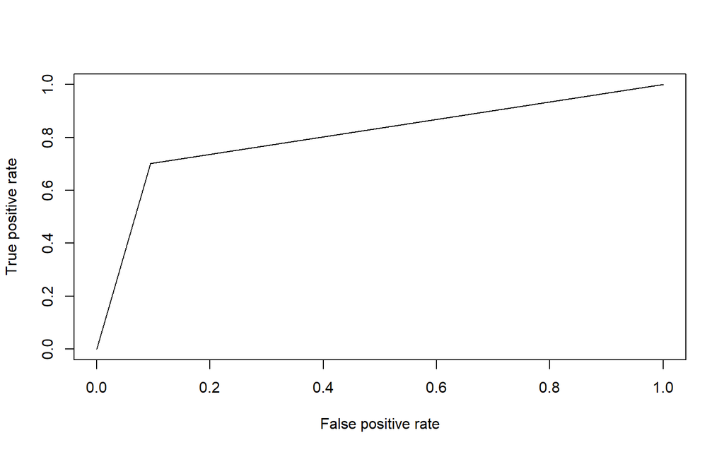

```r
predSVM <- prediction(as.numeric(pred.valid.svm), as.numeric(test.set$Survived))
perfSVM <- performance(predSVM, "tpr", "fpr")
plot(perfSVM)
```

```r
indicadores.calidad(matrizConfusionSVM)
```

```
##   Precision.Global Error.Global Precision.Positiva Precision.Negativa
## 1         0.822695     0.177305          0.7017544          0.9047619
##   Falsos.Positivos Falsos.Negativos Asertividad.Positiva
## 1        0.2982456        0.0952381            0.8333333
##   Asertividad.Negatividad
## 1               0.8172043
```

Lineal

```r
set.seed(1234)
clasificadorSVM <- e1071::svm(Survived ~ ., data = datos.train,
                       type = 'C-classification', kernel = 'linear')
```

```r
pred.valid.svm <- predict(clasificadorSVM, newdata = datos.test)
matrizConfusionSVM <- table(test.set$Survived, pred.valid.svm)
matrizConfusionSVM
```

```
##     pred.valid.svm
##      No Si
##   No 76  8
##   Si 17 40
```

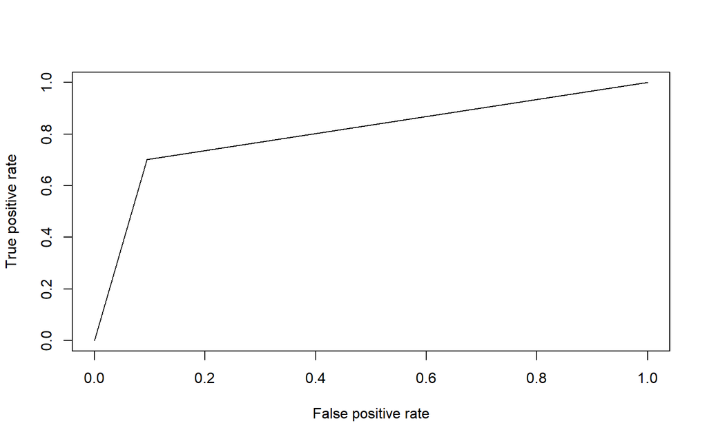

```r
predSVM <- prediction(as.numeric(pred.valid.svm), as.numeric(test.set$Survived))
perfSVM <- performance(predSVM, "tpr", "fpr")
plot(perfSVM)
```

```r
indicadores.calidad(matrizConfusionSVM)
```

```
##   Precision.Global Error.Global Precision.Positiva Precision.Negativa
## 1         0.822695     0.177305          0.7017544          0.9047619
##   Falsos.Positivos Falsos.Negativos Asertividad.Positiva
## 1        0.2982456        0.0952381            0.8333333
##   Asertividad.Negatividad
## 1               0.8172043
```

polynomial

```r
set.seed(1234)
clasificadorSVM <- e1071::svm(Survived ~ ., data = datos.train,
                       type = 'C-classification', kernel = 'polynomial')
```

```r
pred.valid.svm <- predict(clasificadorSVM, newdata = datos.test)
matrizConfusionSVM <- table(test.set$Survived, pred.valid.svm)
matrizConfusionSVM
```

```
##     pred.valid.svm
##      No Si
##   No 82  2
##   Si 56  1
```

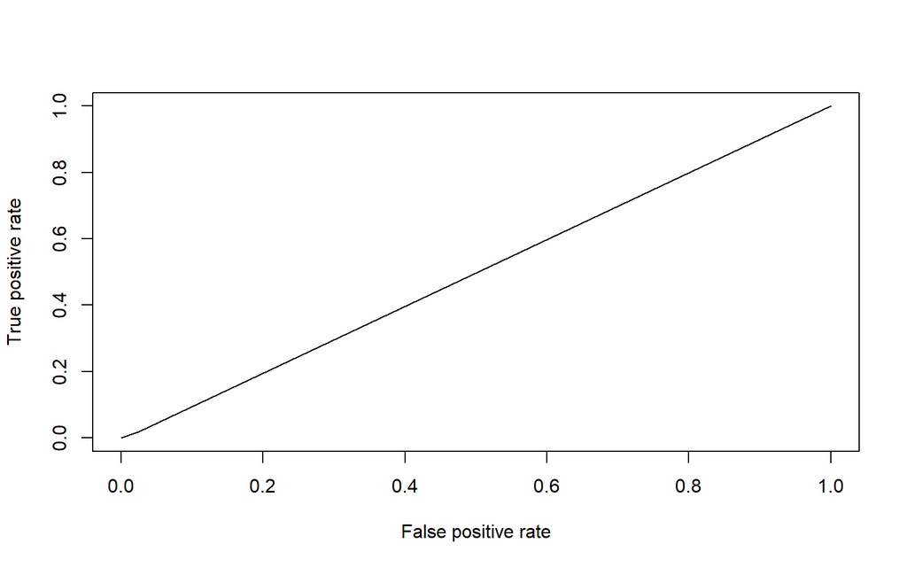

```r
predSVM <- prediction(as.numeric(pred.valid.svm), as.numeric(test.set$Survived))
perfSVM <- performance(predSVM, "tpr", "fpr")
plot(perfSVM)
```

```r
indicadores.calidad(matrizConfusionSVM)
```

```
##   Precision.Global Error.Global Precision.Positiva Precision.Negativa
## 1        0.5886525    0.4113475         0.01754386          0.9761905
##   Falsos.Positivos Falsos.Negativos Asertividad.Positiva
## 1        0.9824561       0.02380952            0.3333333
##   Asertividad.Negatividad
## 1               0.5942029
```

sigmoid

```r
set.seed(1234)
clasificadorSVM <- e1071::svm(Survived ~ ., data = datos.train,
                       type = 'C-classification', kernel = 'sigmoid')
```

```r
pred.valid.svm <- predict(clasificadorSVM, newdata = datos.test)
matrizConfusionSVM <- table(test.set$Survived, pred.valid.svm)
matrizConfusionSVM
```

```
##     pred.valid.svm
##      No Si
##   No 76  8
##   Si 14 43
```

Curva ROC de Nucleo sigmoid

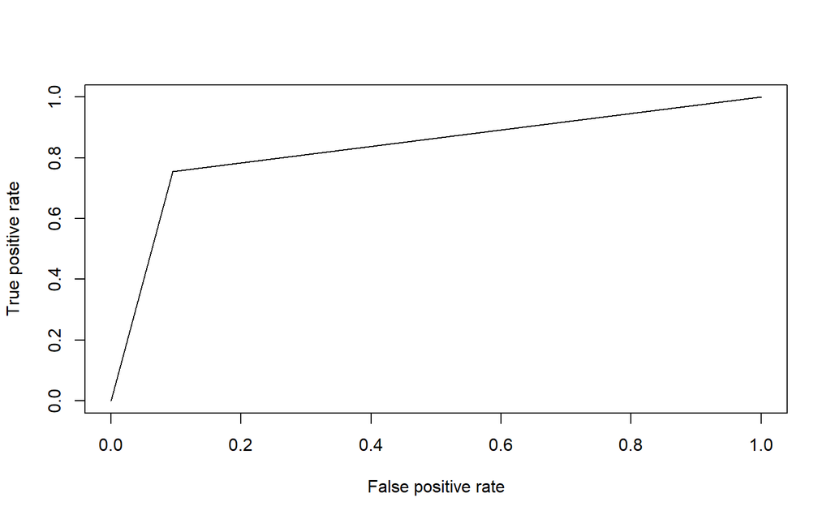

```r
predSVM <- prediction(as.numeric(pred.valid.svm), as.numeric(test.set$Survived))
perfSVM <- performance(predSVM, "tpr", "fpr")
plot(perfSVM)
```

```r
indicadores.calidad(matrizConfusionSVM)
```

```
##   Precision.Global Error.Global Precision.Positiva Precision.Negativa
## 1        0.8439716    0.1560284           0.754386          0.9047619
##   Falsos.Positivos Falsos.Negativos Asertividad.Positiva
## 1         0.245614        0.0952381            0.8431373
##   Asertividad.Negatividad
## 1               0.8444444
```

En este caso el mejor nucleo es el sigmoide.

## 3. Entrene los demás modelos:

1. Bayes

```r
set.seed(1234)
clasificadorBayes <- naiveBayes(Survived ~ ., data = datos.train)
pred.valid.bayes <- predict(clasificadorBayes, newdata = datos.test)
matrizConfusionBayes <- table(datos.test$Survived, pred.valid.bayes)
matrizConfusionBayes
```

```
##     pred.valid.bayes
##      No Si
##   No 72 12
##   Si 22 35
```

Indicadores de calidad

```r
indicadores.calidad(matrizConfusionBayes)
```

```
##   Precision.Global Error.Global Precision.Positiva Precision.Negativa
## 1        0.7588652    0.2411348          0.6140351          0.8571429
##   Falsos.Positivos Falsos.Negativos Asertividad.Positiva
## 1        0.3859649        0.1428571            0.7446809
##   Asertividad.Negatividad
## 1               0.7659574
```

Curva ROC de Bayes.

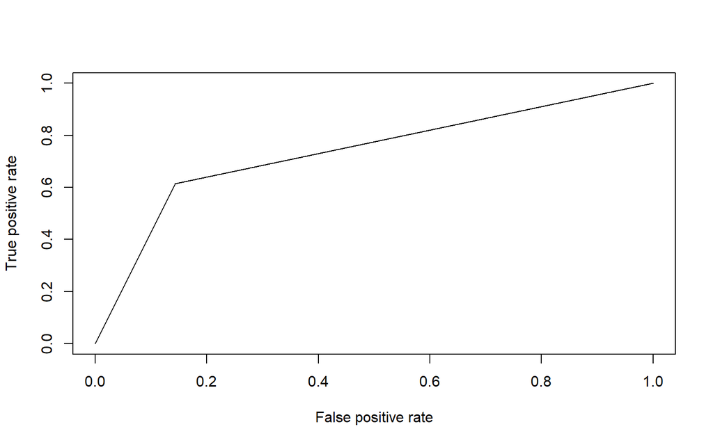

```r
predBayes <- prediction(as.numeric(pred.valid.bayes), as.numeric(test.set$Survived))
perfBayes <- performance(predBayes, "tpr", "fpr")
plot(perfBayes)
```

2. Árboles

```r
set.seed(1234)
clasificadorDT <- rpart(Survived ~ ., data = datos.train)
pred.valid.DT <- predict(clasificadorDT, newdata = datos.test, type = 'class')
matrizConfusionDT <- table(datos.test$Survived, pred.valid.DT)
```

Indicadores de Calidad de arboles

```r
indicadores.calidad(matrizConfusionDT)
```

```
##   Precision.Global Error.Global Precision.Positiva Precision.Negativa
## 1        0.8014184    0.1985816          0.6842105          0.8809524
##   Falsos.Positivos Falsos.Negativos Asertividad.Positiva
## 1        0.3157895        0.1190476            0.7959184
##   Asertividad.Negatividad
## 1               0.8043478
```

Curva ROC de arboles

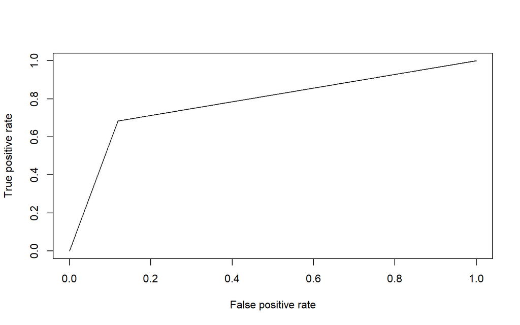

```r
predDT <- prediction(as.numeric(pred.valid.DT), as.numeric(datos.test$Survived))
perfDT <- performance(predDT, "tpr", "fpr")
plot(perfDT)
```

3. Bosques Aleatorios

```r
clasificadorRF <- randomForest(Survived ~ ., data = datos.train, ntree = 250)
```

```r
pred.valid.RF <- predict(clasificadorRF, newdata = datos.test)
matrizConfusionRF <- table(datos.test$Survived, pred.valid.RF)
matrizConfusionRF
```

```
##     pred.valid.RF
##      No Si
##   No 72 12
##   Si 14 43
```

Indicadores de Calidad de Random Forest

```r
indicadores.calidad(matrizConfusionRF)
```

```
##   Precision.Global Error.Global Precision.Positiva Precision.Negativa
## 1        0.8156028    0.1843972           0.754386          0.8571429
##   Falsos.Positivos Falsos.Negativos Asertividad.Positiva
## 1         0.245614        0.1428571            0.7818182
##   Asertividad.Negatividad
## 1               0.8372093
```

4. Regresión Logística

```r
RL <- glm(Survived ~ ., family = binomial, data = datos.train)
summary(RL)
```

```
##
## Call:
## glm(formula = Survived ~ ., family = binomial, data = datos.train)
##
## Deviance Residuals:
##     Min       1Q   Median       3Q      Max
## -3.3270  -0.6190  -0.4143   0.6570   2.3015
##
## Coefficients:
##                    Estimate Std. Error z value Pr(>|z|)
## (Intercept)       3.221e+00  7.098e-01   4.538 5.68e-06 ***
## Pclass2          -8.782e-01  4.041e-01  -2.173 0.029755 *
## Pclass3          -1.772e+00  4.302e-01  -4.120 3.79e-05 ***
## Sexmale          -2.455e+00  2.536e-01  -9.683  < 2e-16 ***
## Age              -2.440e-02  1.335e-02  -1.827 0.067648 .
## SibSp1           -1.731e-01  2.802e-01  -0.618 0.536775
## SibSp2           -6.946e-01  7.120e-01  -0.976 0.329298
## SibSp3           -4.128e+00  1.084e+00  -3.807 0.000141 ***
## SibSp4           -2.763e+00  9.366e-01  -2.950 0.003179 **
## SibSp5           -1.659e+01  9.655e+02  -0.017 0.986290
## Parch1           -1.515e-01  3.802e-01  -0.398 0.690321
## Parch2           -2.506e-02  5.099e-01  -0.049 0.960806
## Parch3            3.862e-01  1.065e+00   0.363 0.716826
## Parch4           -1.641e+01  1.060e+03  -0.015 0.987650
## Parch5           -6.643e-01  1.276e+00  -0.520 0.602721
## Parch6           -1.663e+01  2.400e+03  -0.007 0.994472
## Fare              7.834e-03  4.815e-03   1.627 0.103708
## EmbarkedQ        -9.488e-01  6.443e-01  -1.473 0.140877
## EmbarkedS        -5.680e-01  3.386e-01  -1.677 0.093454 .
## Age.grupoadulto   3.422e-02  4.248e-01   0.081 0.935784
## Age.grupoanciano  1.503e-01  9.478e-01   0.159 0.873993
## Age.gruponiño     1.937e+00  6.732e-01   2.877 0.004010 **
## ---
## Signif. codes:  0 '***' 0.001 '**' 0.01 '*' 0.05 '.' 0.1 ' ' 1
##
## (Dispersion parameter for binomial family taken to be 1)
##
##     Null deviance: 770.64  on 570  degrees of freedom
## Residual deviance: 493.03  on 549  degrees of freedom
## AIC: 537.03
##
## Number of Fisher Scoring iterations: 15
```

```r
pred.train <- predict(RL, type = 'response', ndata = datos.train)
pred.train <- ifelse(pred.train > 0.5, 1, 0)
pred.train <- factor(pred.train, levels = c("0", "1"), labels = c("No", "Si"))
```

```r
matrizConfusionTRL <- table(datos.train$Survived, pred.train)
matrizConfusionTRL
```

```
##     pred.train
##       No  Si
##   No 291  49
##   Si  56 175
```

Matriz de confusión en conjunto

```r
pred.valid <- predict(RL, type = 'response', newdata = datos.test)
pred.valid <- ifelse(pred.valid > 0.5, 1, 0)
pred.valid <- factor(pred.valid, levels = c("0", "1"), labels = c("No", "Si"))
matrizConfusionPRL <- table(test.set$Survived, pred.valid)
matrizConfusionPRL
```

```
##     pred.valid
##      No Si
##   No 73 11
##   Si 13 44
```

```r
indicadores.calidad(matrizConfusionPRL)
```

```
##   Precision.Global Error.Global Precision.Positiva Precision.Negativa
## 1        0.8297872    0.1702128          0.7719298          0.8690476
##   Falsos.Positivos Falsos.Negativos Asertividad.Positiva
## 1        0.2280702        0.1309524                  0.8
##   Asertividad.Negatividad
## 1               0.8488372
```

```r
precision<-c((matrizConfusionTRL[1,1] + matrizConfusionTRL[2,2])/sum(matrizConfusionTRL),
            (matrizConfusionBayes[1,1] + matrizConfusionBayes[2,2])/sum(matrizConfusionBayes),
            (matrizConfusionDT[1,1] + matrizConfusionDT[2,2])/sum(matrizConfusionDT),
            (matrizConfusionRF[1,1] + matrizConfusionRF[2,2])/sum(matrizConfusionRF),
            (matrizConfusionSVM[1,1] + matrizConfusionSVM[2,2])/sum(matrizConfusionSVM)
             )

curva.ROC<-c(auc.prl@y.values[[1]],
             auc.pBayes@y.values[[1]],
             auc.pDT@y.values[[1]],
             auc.pRF@y.values[[1]],
             auc.pSVM@y.values[[1]])

resultados<-data.frame(
  Precisión = precision,
  Error = 1-precision,
  ROC = curva.ROC
)

row.names(resultados)<-c("Regresión Logística","Bayes","Árboles","Bosques","Máquinas")

DT:::datatable(resultados)%>%
            formatPercentage(colnames(resultados),2)
```

|  | Precisión | Error | ROC |
| --- | --- | --- | --- |
| Regresión Logística | 0.816112084063047 | 0.183887915936953 | 0.903959449785858 |
| Bayes | 0.75886524822695 | 0.24113475177305 | 0.902305289268792 |
| Árboles | 0.801418439716312 | 0.198581560283688 | 0.902575260305697 |
| Bosques | 0.815602836879433 | 0.184397163120567 | 0.914509014869102 |
| Máquinas | 0.843971631205674 | 0.156028368794326 | 0.901055144641451 |

## 5. Realice 20 veces la calibración de estos modelos (utilizar el código visto en clases)